# Final analysis

# Data cleaning

## Load libraries

```r
library(tidyverse)
library(skimr)
library(knitr)
library(cowplot)
library(patchwork)
library(broom)
library(haven)
library(lubridate)
library(car)
library(parallel)
library(brms)
library(bayesplot)
library(tidybayes)
library(shinystan)
```

Set `cache = TRUE` as global option:

```r
knitr::opts_chunk$set(cache = TRUE)
```

## Import and clean data

Import the SPSS file. (It’s better to import this versus a CSV file because the SPSS file has labels we can use to check that we’re grabbing the right variables.)

```r
YA_spss <- read_sav("./data/NATSAP_YA_full.sav")
```

```r
names(YA_spss)
```

```
  [1] "clientNumber"
  [2] "ep01_otClientId"
  [3] "ep01_facility_facilityId"
  [4] "ep01_facility_company_subgroup"
  [5] "ep01_gender"
  [6] "ep01_ethnicity"
  [7] "ep01_dob"
  [8] "ep01_doa"
  [9] "ep01_dod"
 [10] "ep01_instance_today"
 [11] "ep01_age_group_at_admit"
 [12] "ep01_active_now"
 [13] "ep01_client_consent"
 [14] "ep01_relative_consent"
 [15] "ep01_has_filter_autism"
```

[output cut: 314 more lines]

### Locate variables of interest

#### Demographic data

Gender:

```r
str(YA_spss$GENDER)
```

```
 dbl+lbl [1:5340] 2, 2, 2, 1, 2, 2, 2, 1, 1, 1, 2, 2, 2, 2, 1, 2, 2, 2, 1, 1, 1,...
 @ format.spss  : chr "F8.2"
 @ display_width: int 10
 @ labels       : Named num [1:2] 1 2
  ..- attr(*, "names")= chr [1:2] "FEMALE" "MALE"
```

Date of birth is `YA_spss$ep01_dob`.

Date of admission is `YA_spss$ep01_doa`.

Date of discharge is `YA_spss$ep01_dod`.

#### Ethnicity

This appears in two places:

```r
str(YA_spss$ep01_ethnicity)
```

```
 chr [1:5340] "Caucasian" "" "" "" "Caucasian" "" "" "Caucasian" "" "Caucasian" ...
 - attr(*, "format.spss")= chr "A44"
 - attr(*, "display_width")= int 44
```

```r
str(YA_spss$ep01_client_NATSAP_ADULT_I_A0_Q17)
```

```
 dbl+lbl [1:5340]  5,  3,  5, NA,  5, NA, NA,  5,  5,  5,  5, NA,  6,  3,  5,  1...
 @ label      : chr "Your ethnicity"
 @ format.spss: chr "F1.0"
 @ labels     : Named num [1:6] 1 2 3 4 5 6
  ..- attr(*, "names")= chr [1:6] "African American" "Asian American" "Hispanic" "Native American" ...
```

Do the two columns agree?

```r
check_ethnicity <- YA_spss %>%
    select(ethnicity1 = ep01_ethnicity,
           ethnicity2 = ep01_client_NATSAP_ADULT_I_A0_Q17) %>%
    transmute(ethnicity1 = as_factor(ethnicity1),
              ethnicity2 = as_factor(ethnicity2)) %>%
    group_by(ethnicity1, ethnicity2) %>%
    summarise(count = n(), .groups = "drop")
check_ethnicity
```

| ethnicity1 | ethnicity2 | count |
| --- | --- | --- |
| Caucasian | African American | 2 |
| Caucasian | Asian American | 1 |
| Caucasian | Hispanic | 20 |
| Caucasian | Native American | 5 |
| Caucasian | White | 840 |
| Caucasian | Other | 25 |
| Caucasian | NA | 355 |
|  | African American | 31 |
|  | Asian American | 78 |
|  | Hispanic | 105 |

[output cut: 47 more lines]

No, they don’t match. We’ll have to do some cleaning to merge these columns. We’ll do this after we subset columns and remove data with missing values in key variables.

#### Intake questions

Affective motivation:

```r
str(YA_spss$ep01_client_NATSAP_ADULT_I_A0_Q10)
```

```
 dbl+lbl [1:5340]  5,  5,  4, NA,  4, NA, NA,  5,  4,  4,  3, NA,  5,  5,  4,  5...
 @ label      : chr "How do you feel about being at this program?"
 @ format.spss: chr "F1.0"
 @ labels     : Named num [1:5] 1 2 3 4 5
  ..- attr(*, "names")= chr [1:5] "Very negative" "Negative" "Neutral" "Somewhat positive" ...
```

Cognitive motivation:

```r
str(YA_spss$ep01_client_NATSAP_ADULT_I_A0_Q13)
```

```
 num [1:5340] 76 100 71 NA 97 NA NA 90 81 96 ...
 - attr(*, "label")= chr "It makes sense for me to be in a therapeutic program:"
 - attr(*, "format.spss")= chr "F3.0"
```

#### Discharge questions:

Satisfaction:

```r
str(YA_spss$ep01_client_NATSAP_ADULT_D_D0_Q5)
```

```
 dbl+lbl [1:5340] NA, NA, NA, NA, NA, NA, NA, NA, NA, NA, NA, NA, NA, NA, NA, NA...
 @ label      : chr "Currently how satisfied are you with the quality of treatment you re"
 @ format.spss: chr "F1.0"
 @ labels     : Named num [1:5] 1 2 3 4 5
  ..- attr(*, "names")= chr [1:5] "Very dissatisfied" "Somewhat dissatisfied" "Neutral" "Somewhat satisfied" ...
```

Effort:

```r
str(YA_spss$ep01_client_NATSAP_ADULT_D_D0_Q6)
```

```
 dbl+lbl [1:5340] NA, NA, NA, NA, NA, NA, NA, NA, NA, NA, NA, NA, NA, NA, NA, NA...
 @ label      : chr "How much effort did you put into your treatment at the program?"
 @ format.spss: chr "F1.0"
 @ labels     : Named num [1:5] 1 2 3 4 5
  ..- attr(*, "names")= chr [1:5] "No effort" "Little effort" "Average effort" "Above average effort" ...
```

#### OQ scores

Admit OQ:

```r
str(YA_spss$OQ_452_A_Total)
```

```
 num [1:5340] 130 51 70 NA 118 NA NA 96 92 141 ...
 - attr(*, "format.spss")= chr "F3.0"
 - attr(*, "display_width")= int 21
```

Discharge OQ:

```r
str(YA_spss$OQ_452_D_Total)
```

```
 num [1:5340] NA NA NA NA NA NA NA NA NA NA ...
 - attr(*, "format.spss")= chr "F3.0"
 - attr(*, "display_width")= int 18
```

#### Program variables

Facility type:

```r
str(YA_spss$FacilityType)
```

```
 dbl+lbl [1:5340] 1, 1, 1, 1, 1, 1, 1, 1, 1, 1, 1, 1, 1, 1, 1, 1, 1, 1, 1, 1, 1,...
 @ format.spss  : chr "F8.2"
 @ display_width: int 18
 @ labels       : Named num [1:2] 1 2
  ..- attr(*, "names")= chr [1:2] "Residential Treatment Center" "OBH"
```

### Select and format variables

```r
YA_clean_full <- YA_spss %>%
    dplyr::select(
        gender = GENDER,
        ethnicity1 = ep01_ethnicity,
        ethnicity2 = ep01_client_NATSAP_ADULT_I_A0_Q17,
        dob = ep01_dob,
        doa = ep01_doa,
        dod = ep01_dod,
        affective_motivation =
           ep01_client_NATSAP_ADULT_I_A0_Q10,
        cognitive_motivation =
           ep01_client_NATSAP_ADULT_I_A0_Q13,
        satisfaction = ep01_client_NATSAP_ADULT_D_D0_Q5,
        effort = ep01_client_NATSAP_ADULT_D_D0_Q6,
        OQ_admit = OQ_452_A_Total,
        OQ_discharge = OQ_452_D_Total,
        facility = ep01_facility_company,
        facility_type = FacilityType
           )
```

### Deal with date variables

Convert date variables to `datetime` format (for use with the `lubridate` package):

```r
YA_clean_full <- YA_clean_full %>%
    mutate(dob = as_datetime(dob),
           doa = as_datetime(doa),
           dod = as_datetime(dod))
```

Calculate age at admission:

```r
YA_clean_full <- YA_clean_full %>%
    mutate(age_at_admit = as.duration(interval(dob, doa)) %/%
               as.duration(years(1)))
```

### Remove values not from population of interest

```r
YA_clean_full <- YA_clean_full %>%
    filter(facility != "Morningside Recovery") %>%
    filter(age_at_admit < 30)
```

### Deal with factor variables:

```r
YA_clean_full$gender <- as_factor(YA_clean_full$gender)
YA_clean_full$ethnicity1 <- as_factor(YA_clean_full$ethnicity1)
YA_clean_full$ethnicity2 <- as_factor(YA_clean_full$ethnicity2)
YA_clean_full$affective_motivation <-
    as_factor(YA_clean_full$affective_motivation)
YA_clean_full$satisfaction <-
    as_factor(YA_clean_full$satisfaction)
YA_clean_full$effort <- as_factor(YA_clean_full$effort)
YA_clean_full$facility_type <- as_factor(YA_clean_full$facility_type)
```

Rename factors in `facility_type`. The current levels are:

```r
levels(YA_clean_full$facility_type)
```

```
[1] "Residential Treatment Center" "OBH"
```

We change “Residential Treatment Center” to “RTC” for convenience:

```r
levels(YA_clean_full$facility_type) <- c("RTC", "OBH")
levels(YA_clean_full$facility_type)
```

```
[1] "RTC" "OBH"
```

### Full data set (with missing values)

```r
skim(YA_clean_full) %>%
    knit_print()
```

Data summary

| Name | YA_clean_full |
| --- | --- |
| Number of rows | 3823 |
| Number of columns | 15 |
| _______________________ |  |
| Column type frequency: |  |
| character | 1 |
| factor | 7 |
| numeric | 4 |
| POSIXct | 3 |
| ________________________ |  |
| Group variables | None |

**Variable type: character**

| skim_variable | n_missing | complete_rate | min | max | empty | n_unique | whitespace |
| --- | --- | --- | --- | --- | --- | --- | --- |
| facility | 0 | 1 | 5 | 41 | 0 | 53 | 0 |

**Variable type: factor**

| skim_variable | n_missing | complete_rate | ordered | n_unique | top_counts |
| --- | --- | --- | --- | --- | --- |
| gender | 159 | 0.96 | FALSE | 2 | MAL: 2577, FEM: 1087 |
| ethnicity1 | 0 | 1.00 | FALSE | 14 | emp: 3112, Cau: 463, Not: 132, 0: 29 |
| ethnicity2 | 1363 | 0.64 | FALSE | 6 | Whi: 2131, Oth: 110, His: 96, Asi: 76 |
| affective_motivation | 1354 | 0.65 | FALSE | 5 | Som: 859, Ver: 747, Neu: 577, Neg: 192 |
| satisfaction | 1856 | 0.51 | FALSE | 5 | Ver: 1441, Som: 325, Neu: 108, Ver: 53 |
| effort | 1860 | 0.51 | FALSE | 5 | Max: 932, Abo: 830, Ave: 176, Lit: 16 |
| facility_type | 47 | 0.99 | FALSE | 2 | OBH: 2886, RTC: 890 |

**Variable type: numeric**

| skim_variable | n_missing | complete_rate | mean | sd | p0 | p25 | p50 | p75 | p100 | hist |
| --- | --- | --- | --- | --- | --- | --- | --- | --- | --- | --- |
| cognitive_motivation | 1390 | 0.64 | 74.78 | 23.17 | 0 | 61 | 77 | 98 | 100 | ▁▁▃▆▇ |
| OQ_admit | 1133 | 0.70 | 77.21 | 25.58 | 0 | 60 | 78 | 94 | 160 | ▁▅▇▃▁ |
| OQ_discharge | 1594 | 0.58 | 50.25 | 23.23 | 0 | 35 | 49 | 64 | 144 | ▃▇▅▁▁ |
| age_at_admit | 0 | 1.00 | 20.65 | 2.64 | 17 | 19 | 20 | 22 | 29 | ▇▅▃▁▁ |

**Variable type: POSIXct**

| skim_variable | n_missing | complete_rate | min | max | median | n_unique |
| --- | --- | --- | --- | --- | --- | --- |
| dob | 0 | 1.00 | 1982-02-02 | 2000-09-11 | 1995-09-20 | 2385 |
| doa | 0 | 1.00 | 2010-02-26 | 2018-10-09 | 2016-08-30 | 1642 |
| dod | 350 | 0.91 | 2010-08-24 | 2019-01-26 | 2016-10-24 | 1441 |

### Write full data to file

```r
write_csv(YA_clean_full, "./data/YA_data_clean_full.csv")
```

### Remove missing data

`YA_clean_full` was the full data set. Now we remove missing data and call it `YA`.

```r
YA <- YA_clean_full %>%
    drop_na(gender, age_at_admit,
            affective_motivation, cognitive_motivation,
            satisfaction, effort,
            OQ_admit, OQ_discharge,
            facility, facility_type)
```

### Assign random IDs to facilities

Number of facilities:

```r
fac_list <- unique(YA$facility)
```

```r
n_fac <- length(fac_list)
n_fac
```

```
[1] 21
```

Generate random ID numbers:

```r
set.seed(1)
fac_ID <- sample(1:n_fac)
fac_ID
```

```
 [1]  4  7  1  2 11 14 18 17  3 19  5 16  6  9 15 12 10  8 21 13 20
```

Create lookup table:

```r
names(fac_ID) <- fac_list
```

Assign new IDs for each facility:

```r
YA$fac_ID <- fac_ID[YA$facility]
```

### Ordered factors for Likert scales

Create ordered factors from Likert scales:

```r
table(YA$affective_motivation)
```

```
    Very negative          Negative           Neutral Somewhat positive
               55               114               353               507
    Very positive
              394
```

```r
YA$affective_motivation <- factor(YA$affective_motivation,
        levels = c("Very negative",
                   "Negative",
                   "Neutral",
                   "Somewhat positive",
                   "Very positive"),
        ordered = TRUE)
table(YA$affective_motivation)
```

```
    Very negative          Negative           Neutral Somewhat positive
               55               114               353               507
    Very positive
              394
```

```r
table(YA$satisfaction)
```

```
    Very dissatisfied Somewhat dissatisfied               Neutral
                   36                    26                    71
   Somewhat satisfied        Very satisfied
                  248                  1042
```

```r
YA$satisfaction <- factor(YA$satisfaction,
        levels = c("Very dissatisfied",
                   "Somewhat dissatisfied",
                   "Neutral",
                   "Somewhat satisfied",
                   "Very satisfied"),
        ordered = TRUE)
table(YA$satisfaction)
```

```
    Very dissatisfied Somewhat dissatisfied               Neutral
                   36                    26                    71
   Somewhat satisfied        Very satisfied
                  248                  1042
```

```r
table(YA$effort)
```

```
           No effort        Little effort       Average effort Above average effort
                   6                   11                  121                  597
      Maximum effort
                 688
```

```r
YA$effort <- factor(YA$effort,
        levels = c("No effort",
                   "Little effort",
                   "Average effort",
                   "Above average effort",
                   "Maximum effort"),
        ordered = TRUE)
table(YA$effort)
```

```
           No effort        Little effort       Average effort Above average effort
                   6                   11                  121                  597
      Maximum effort
                 688
```

### Center continuous variables

#### OQ admit:

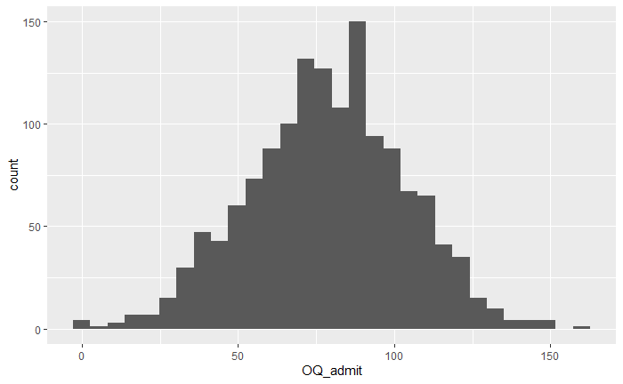

```r
ggplot(YA, aes(x = OQ_admit)) +
    geom_histogram()
```

```r
mean(YA$OQ_admit)
```

```
[1] 78.487
```

#### Age at admit:

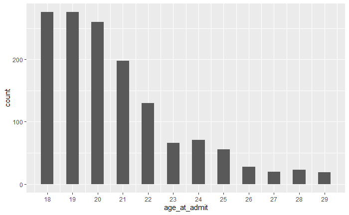

```r
ggplot(YA, aes(x = age_at_admit)) +
    geom_histogram(binwidth = 0.5, center = 0) +
    scale_x_continuous(breaks = seq(from = 18, to = 30))
```

```r
median(YA$age_at_admit)
```

```
[1] 20
```

#### Cognitive motivation:

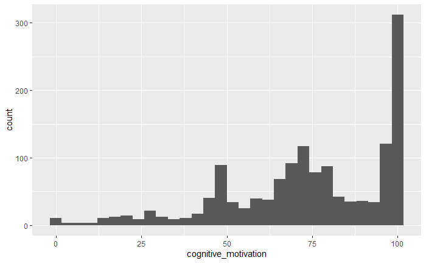

```r
ggplot(YA, aes(x = cognitive_motivation)) +
    geom_histogram()
```

```r
median(YA$cognitive_motivation)
```

```
[1] 75
```

Center using either mean or median:

```r
YA$OQ_admit_meanc <- YA$OQ_admit - mean(YA$OQ_admit)
YA$age_at_admit_medc <-
    YA$age_at_admit - median(YA$age_at_admit)
YA$cognitive_motivation_medc <-
    YA$cognitive_motivation - median(YA$cognitive_motivation)
```

### Deal with ethnicity

```r
YA %>%
    unite("ethnicity", ethnicity1, ethnicity2, sep = "") %>%
    group_by(ethnicity) %>%
    summarize(count = n(), .groups = "drop") %>%
    as.data.frame() %>%
    print()
```

| ethnicity | count |
| --- | --- |
| 0Hispanic | 1 |
| 0White | 7 |
| African American | 15 |
| African AmericanAfrican American | 1 |
| Asian American | 40 |
| AsianAsian American | 1 |
| CaucasianHispanic | 1 |
| CaucasianWhite | 75 |
| Hispanic | 47 |
| Hispanic or LatinoHispanic | 2 |

[output cut: 12 more lines]

We just have to list these all out manually and classify them correctly.

```r
YA <- YA %>%
    unite("ethnicity", ethnicity1, ethnicity2, sep = "") %>%
    mutate(ethnicity_final =
        case_when(
            ethnicity == "0Hispanic" ~ "Hispanic/Latino",
            ethnicity == "0White" ~ "White",
            ethnicity == "African American" ~ "African American",
            ethnicity == "African AmericanAfrican American" ~
                "African American",
            ethnicity == "Asian American" ~ "Asian American",
            ethnicity == "AsianAsian American" ~ "Asian American",
            ethnicity == "CaucasianHispanic" ~ "Other",
            ethnicity == "CaucasianWhite" ~ "White",
            ethnicity == "Hispanic" ~ "Hispanic/Latino",
            ethnicity == "Hispanic or LatinoHispanic" ~
                "Hispanic/Latino",
            ethnicity == "Hispanic or LatinoOther" ~ "Other",
            ethnicity == "Hispanic/LatinoHispanic" ~
                "Hispanic/Latino",
            ethnicity == "Multi-EthnicOther" ~ "Other",
            ethnicity == "NA" ~ "Missing",
            ethnicity == "Native American" ~ "Native American",
            ethnicity == "Not Hispanic or LatinoAfrican American" ~
                "African American",
            ethnicity == "Not Hispanic or LatinoAsian American" ~
                "Asian American",
            ethnicity == "Not Hispanic or LatinoNative American" ~
                "Native American",
            ethnicity == "Not Hispanic or LatinoOther" ~ "Other",
            ethnicity == "Not Hispanic or LatinoWhite" ~ "White",
            ethnicity == "Other" ~ "Other",
            ethnicity == "White" ~ "White"))
```

```r
YA %>%
    group_by(ethnicity_final) %>%
    summarize(count = n(), .groups = "drop") %>%
    as.data.frame() %>%
    print()
```

| ethnicity_final | count |
| --- | --- |
| African American | 17 |
| Asian American | 42 |
| Hispanic/Latino | 54 |
| Missing | 12 |
| Native American | 7 |
| Other | 52 |
| White | 1239 |

## Final data set

```r
skim(YA) %>%
    knit_print()
```

Data summary

| Name | YA |
| --- | --- |
| Number of rows | 1423 |
| Number of columns | 19 |
| _______________________ |  |
| Column type frequency: |  |
| character | 3 |
| factor | 5 |
| numeric | 8 |
| POSIXct | 3 |
| ________________________ |  |
| Group variables | None |

**Variable type: character**

| skim_variable | n_missing | complete_rate | min | max | empty | n_unique | whitespace |
| --- | --- | --- | --- | --- | --- | --- | --- |
| ethnicity | 0 | 1 | 2 | 38 | 0 | 22 | 0 |
| facility | 0 | 1 | 5 | 33 | 0 | 21 | 0 |
| ethnicity_final | 0 | 1 | 5 | 16 | 0 | 7 | 0 |

**Variable type: factor**

| skim_variable | n_missing | complete_rate | ordered | n_unique | top_counts |
| --- | --- | --- | --- | --- | --- |
| gender | 0 | 1 | FALSE | 2 | MAL: 1035, FEM: 388 |
| affective_motivation | 0 | 1 | TRUE | 5 | Som: 507, Ver: 394, Neu: 353, Neg: 114 |
| satisfaction | 0 | 1 | TRUE | 5 | Ver: 1042, Som: 248, Neu: 71, Ver: 36 |
| effort | 0 | 1 | TRUE | 5 | Max: 688, Abo: 597, Ave: 121, Lit: 11 |
| facility_type | 0 | 1 | FALSE | 2 | OBH: 1320, RTC: 103 |

**Variable type: numeric**

| skim_variable | n_missing | complete_rate | mean | sd | p0 | p25 | p50 | p75 | p100 | hist |
| --- | --- | --- | --- | --- | --- | --- | --- | --- | --- | --- |
| cognitive_motivation | 0 | 1 | 73.86 | 23.70 | 0.00 | 60.00 | 75.00 | 97.00 | 100.00 | ▁▁▃▆▇ |
| OQ_admit | 0 | 1 | 78.49 | 25.08 | 0.00 | 62.00 | 79.00 | 95.00 | 160.00 | ▁▅▇▃▁ |
| OQ_discharge | 0 | 1 | 48.90 | 22.31 | 0.00 | 33.00 | 48.00 | 63.00 | 144.00 | ▃▇▅▁▁ |
| age_at_admit | 0 | 1 | 20.74 | 2.58 | 18.00 | 19.00 | 20.00 | 22.00 | 29.00 | ▇▃▂▁▁ |
| fac_ID | 0 | 1 | 9.83 | 6.57 | 1.00 | 4.00 | 9.00 | 17.00 | 21.00 | ▇▂▁▆▂ |
| OQ_admit_meanc | 0 | 1 | 0.00 | 25.08 | -78.49 | -16.49 | 0.51 | 16.51 | 81.51 | ▁▅▇▃▁ |
| age_at_admit_medc | 0 | 1 | 0.74 | 2.58 | -2.00 | -1.00 | 0.00 | 2.00 | 9.00 | ▇▃▂▁▁ |
| cognitive_motivation_medc | 0 | 1 | -1.14 | 23.70 | -75.00 | -15.00 | 0.00 | 22.00 | 25.00 | ▁▁▃▆▇ |

**Variable type: POSIXct**

| skim_variable | n_missing | complete_rate | min | max | median | n_unique |
| --- | --- | --- | --- | --- | --- | --- |
| dob | 0 | 1 | 1985-01-18 | 2000-05-26 | 1996-04-04 | 1161 |
| doa | 0 | 1 | 2013-07-29 | 2018-09-05 | 2017-01-28 | 836 |
| dod | 0 | 1 | 2013-10-04 | 2018-10-06 | 2017-04-16 | 730 |

### Write final data set to file

```r
write_csv(YA, "./data/YA_data_final.csv")
```

# Data summaries

## Summarize date variables

Date range:

```r
min(YA$doa)
```

```
[1] "2013-07-29 UTC"
```

```r
max(YA$doa)
```

```
[1] "2018-09-05 UTC"
```

```r
min(YA$dod)
```

```
[1] "2013-10-04 UTC"
```

```r
max(YA$dod)
```

```
[1] "2018-10-06 UTC"
```

## Summarize numerical variables

### OQ discharge

```r
summary(YA$OQ_discharge)
```

```
   Min. 1st Qu.  Median    Mean 3rd Qu.    Max.
    0.0    33.0    48.0    48.9    63.0   144.0
```

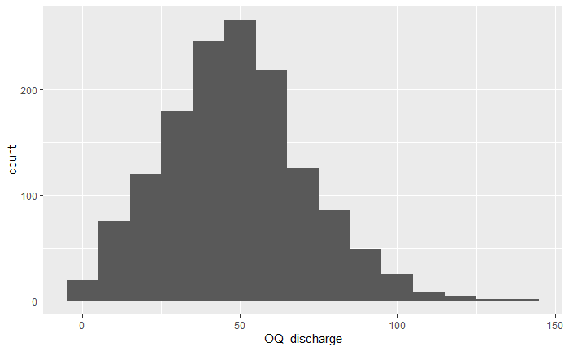

```r
ggplot(YA, aes(x = OQ_discharge)) +
    geom_histogram(binwidth = 10)
```

### OQ admit

```r
summary(YA$OQ_admit)
```

```
   Min. 1st Qu.  Median    Mean 3rd Qu.    Max.
   0.00   62.00   79.00   78.49   95.00  160.00
```

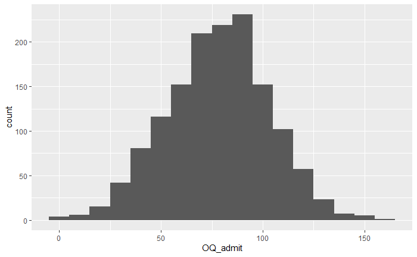

```r
ggplot(YA, aes(x = OQ_admit)) +
    geom_histogram(binwidth = 10)
```

```r
summary(YA$OQ_admit_meanc)
```

```
   Min. 1st Qu.  Median    Mean 3rd Qu.    Max.
-78.487 -16.487   0.513   0.000  16.513  81.513
```

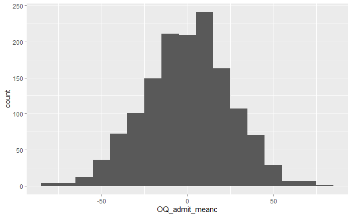

```r
ggplot(YA, aes(x = OQ_admit_meanc)) +
    geom_histogram(binwidth = 10)
```

### Cognitive motivation

```r
summary(YA$cognitive_motivation)
```

```
   Min. 1st Qu.  Median    Mean 3rd Qu.    Max.
   0.00   60.00   75.00   73.86   97.00  100.00
```

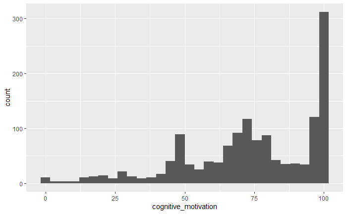

```r
ggplot(YA, aes(x = cognitive_motivation)) +
    geom_histogram()
```

```r
summary(YA$cognitive_motivation_medc)
```

```
   Min. 1st Qu.  Median    Mean 3rd Qu.    Max.
-75.000 -15.000   0.000  -1.136  22.000  25.000
```

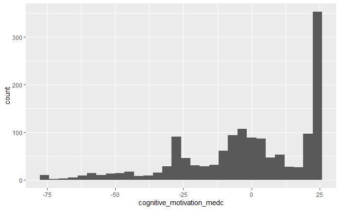

```r
ggplot(YA, aes(x = cognitive_motivation_medc)) +
    geom_histogram()
```

### Age at admit

```r
summary(YA$age_at_admit)
```

```
   Min. 1st Qu.  Median    Mean 3rd Qu.    Max.
  18.00   19.00   20.00   20.74   22.00   29.00
```

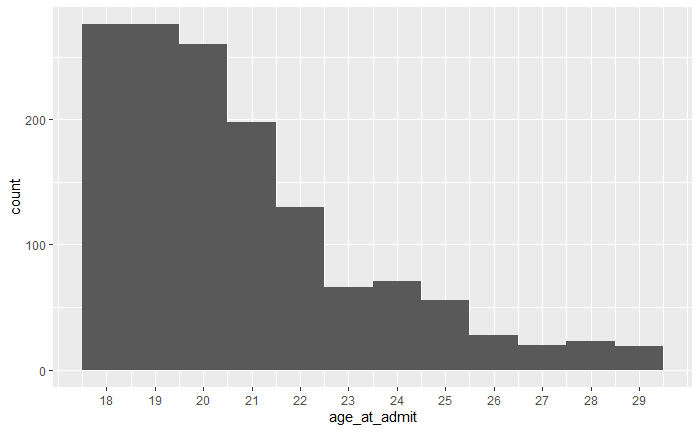

```r
ggplot(YA, aes(x = age_at_admit)) +
    geom_histogram(binwidth = 1) +
    scale_x_continuous(breaks = 18:29)
```

```r
summary(YA$age_at_admit_medc)
```

```
   Min. 1st Qu.  Median    Mean 3rd Qu.    Max.
-2.0000 -1.0000  0.0000  0.7414  2.0000  9.0000
```

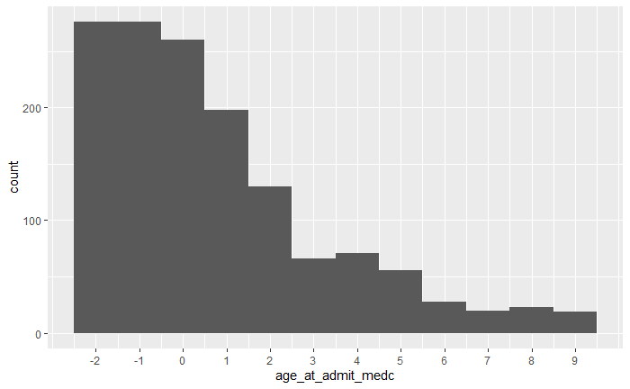

```r
ggplot(YA, aes(x = age_at_admit_medc)) +
    geom_histogram(binwidth = 1) +
    scale_x_continuous(breaks = -2:9)
```

## Summarize categorical variables

### Gender

```r
YA %>%
    group_by(gender) %>%
    summarise(count = n(), .groups = "drop") %>%
    mutate(percent = prop.table(count) * 100)
```

| gender | count | percent |
| --- | --- | --- |
| FEMALE | 388 | 27.26634 |
| MALE | 1035 | 72.73366 |

### Ethnicity

```r
YA %>%
    group_by(ethnicity_final) %>%
    summarise(count = n(), .groups = "drop") %>%
    arrange(desc(count)) %>%
    mutate(percent = prop.table(count) * 100)
```

| ethnicity_final | count | percent |
| --- | --- | --- |
| White | 1239 | 87.0695713 |
| Hispanic/Latino | 54 | 3.7947997 |
| Other | 52 | 3.6542516 |
| Asian American | 42 | 2.9515109 |
| African American | 17 | 1.1946592 |
| Missing | 12 | 0.8432888 |
| Native American | 7 | 0.4919185 |

### Facility

```r
YA %>%
    select(facility, facility_type) %>%
    group_by(facility, facility_type) %>%
    summarise(count = n(), .groups = "drop") %>%
    group_by(facility_type) %>%
    summarise(count = n(), .groups = "drop")
```

| facility_type | count |
| --- | --- |
| RTC | 8 |
| OBH | 13 |

```r
YA %>%
    group_by(facility_type) %>%
    summarise(sample_size = n(), .groups = "drop") %>%
    mutate(percent = prop.table(sample_size) * 100)
```

| facility_type | sample_size | percent |
| --- | --- | --- |
| RTC | 103 | 7.238229 |
| OBH | 1320 | 92.761771 |

# Varying intercept model

## Model code

Default priors are good here:

```r
model_var_int <- brm(
    OQ_discharge ~ 1 +
        (1 | fac_ID) +
        gender +
        OQ_admit_meanc +
        age_at_admit_medc +
        facility_type +
        mo(affective_motivation) +
        cognitive_motivation_medc +
        mo(satisfaction) +
        mo(effort),
    data = YA,
    chains = 3,
    cores = parallel::detectCores() - 1,
    seed = 10,
    save_model = TRUE,
    file = "model_var_int"
    )
```

Check the data and model (especially to understand prior structure):

```r
data_var_int <- standata(model_var_int)
str(data_var_int)
```

```
List of 19
 $ N         : int 1423
 $ Y         : int [1:1423(1d)] 85 89 121 73 72 19 23 118 46 79 ...
 $ K         : int 6
 $ X         : num [1:1423, 1:6] 1 1 1 1 1 1 1 1 1 1 ...
  ..- attr(*, "dimnames")=List of 2
  .. ..$ : chr [1:1423] "1" "2" "3" "4" ...
  .. ..$ : chr [1:6] "Intercept" "genderMALE" "OQ_admit_meanc" "age_at_admit_medc" ...
  ..- attr(*, "assign")= int [1:6] 0 1 2 3 4 5
  ..- attr(*, "contrasts")=List of 2
  .. ..$ gender       : num [1:2, 1] 0 1
  .. .. ..- attr(*, "dimnames")=List of 2
  .. .. .. ..$ : chr [1:2] "FEMALE" "MALE"
  .. .. .. ..$ : chr "MALE"
  .. ..$ facility_type: num [1:2, 1] 0 1
  .. .. ..- attr(*, "dimnames")=List of 2
  .. .. .. ..$ : chr [1:2] "OBH" "RTC"
  .. .. .. ..$ : chr "RTC"
 $ Ksp       : int 3
 $ Imo       : int 3
 $ Xmo_1     : num [1:1423(1d)] 0 0 4 1 1 4 4 0 0 2 ...
 $ Xmo_2     : num [1:1423(1d)] 1 0 1 0 1 0 1 1 1 1 ...
 $ Xmo_3     : num [1:1423(1d)] 4 3 1 2 3 4 4 2 3 2 ...
 $ Jmo       : num [1:3(1d)] 4 4 4
 $ con_simo_1: num [1:4(1d)] 1 1 1 1
 $ con_simo_2: num [1:4(1d)] 1 1 1 1
 $ con_simo_3: num [1:4(1d)] 1 1 1 1
 $ Z_1_1     : num [1:1423(1d)] 1 1 1 1 1 1 1 1 1 1 ...
  ..- attr(*, "dimnames")=List of 1
  .. ..$ : chr [1:1423] "1" "2" "3" "4" ...
 $ J_1       : int [1:1423(1d)] 4 7 1 2 11 14 11 1 4 7 ...
 $ N_1       : int 21
 $ M_1       : int 1
 $ NC_1      : int 0
 $ prior_only: int 0
 - attr(*, "class")= chr [1:2] "standata" "list"
```

```r
model_var_int$model
```

```
// generated with brms 2.13.0
functions {

  /* compute monotonic effects
   * Args:
   *   scale: a simplex parameter
   *   i: index to sum over the simplex
   * Returns:
   *   a scalar between 0 and 1
   */
  real mo(vector scale, int i) {
    if (i == 0) {
      return 0;
    } else {
      return rows(scale) * sum(scale[1:i]);
    }
  }
}
data {
  int<lower=1> N;  // number of observations
  vector[N] Y;  // response variable
  int<lower=1> K;  // number of population-level effects
  matrix[N, K] X;  // population-level design matrix
  int<lower=1> Ksp;  // number of special effects terms
  int<lower=1> Imo;  // number of monotonic variables
  int<lower=1> Jmo[Imo];  // length of simplexes
  // monotonic variables
  int Xmo_1[N];
  int Xmo_2[N];
  int Xmo_3[N];
  // prior concentration of monotonic simplexes
  vector[Jmo[1]] con_simo_1;
  vector[Jmo[2]] con_simo_2;
  vector[Jmo[3]] con_simo_3;
  // data for group-level effects of ID 1
  int<lower=1> N_1;  // number of grouping levels
  int<lower=1> M_1;  // number of coefficients per level
  int<lower=1> J_1[N];  // grouping indicator per observation
  // group-level predictor values
  vector[N] Z_1_1;
```

[output cut: 38 more lines]

```
  target += dirichlet_lpdf(simo_3 | con_simo_3);
  target += student_t_lpdf(sigma | 3, 0, 22.2)
    - 1 * student_t_lccdf(0 | 3, 0, 22.2);
  target += student_t_lpdf(sd_1 | 3, 0, 22.2)
    - 1 * student_t_lccdf(0 | 3, 0, 22.2);
  target += std_normal_lpdf(z_1[1]);
  // likelihood including all constants
  if (!prior_only) {
    target += normal_lpdf(Y | mu, sigma);
  }
}
generated quantities {
  // actual population-level intercept
  real b_Intercept = Intercept - dot_product(means_X, b);
}
```

## Model summary

### Coefficients

```r
summary(model_var_int)
```

```
 Family: gaussian
  Links: mu = identity; sigma = identity
Formula: OQ_discharge ~ 1 + (1 | fac_ID) + gender + OQ_admit_meanc + age_at_admit_medc + facility_type + mo(affective_motivation) + cognitive_motivation_medc + mo(satisfaction) + mo(effort)
   Data: YA (Number of observations: 1423)
  Draws: 3 chains, each with iter = 2000; warmup = 1000; thin = 1;
         total post-warmup draws = 3000

Group-Level Effects:
~fac_ID (Number of levels: 21)
              Estimate Est.Error l-95% CI u-95% CI Rhat Bulk_ESS Tail_ESS
sd(Intercept)     5.68      1.55     3.29     9.38 1.00     1014     1821

Population-Level Effects:
                          Estimate Est.Error l-95% CI u-95% CI Rhat Bulk_ESS
Intercept                    80.47      5.52    70.50    92.27 1.00     1258
genderMALE                    2.24      1.17    -0.01     4.52 1.00     3947
OQ_admit_meanc                0.32      0.02     0.28     0.37 1.00     4180
age_at_admit_medc            -0.04      0.21    -0.43     0.38 1.00     4309
facility_typeRTC             -2.43      3.70   -10.08     4.38 1.00     1254
cognitive_motivation_medc    -0.01      0.02    -0.06     0.04 1.00     3066
moaffective_motivation       -1.31      0.72    -2.79    -0.04 1.00     2207
mosatisfaction               -3.64      0.56    -4.79    -2.57 1.00     2821
moeffort                     -5.37      1.15    -7.81    -3.49 1.00     1621
                          Tail_ESS
Intercept                     1546
genderMALE                    2424
OQ_admit_meanc                1979
age_at_admit_medc             2344
facility_typeRTC              1570
cognitive_motivation_medc     2349
moaffective_motivation        2283
mosatisfaction                2450
moeffort                      1916

Simplex Parameters:
                           Estimate Est.Error l-95% CI u-95% CI Rhat Bulk_ESS
moaffective_motivation1[1]     0.40      0.22     0.03     0.81 1.00     2462
moaffective_motivation1[2]     0.23      0.17     0.01     0.65 1.00     2631
moaffective_motivation1[3]     0.18      0.14     0.01     0.56 1.00     3037
moaffective_motivation1[4]     0.19      0.15     0.01     0.57 1.00     3171
```

[output cut: 14 more lines]

```
mosatisfaction1[2]             1917
mosatisfaction1[3]             1656
mosatisfaction1[4]             2035
moeffort1[1]                   1581
moeffort1[2]                   1413
moeffort1[3]                   1790
moeffort1[4]                   2210

Family Specific Parameters:
      Estimate Est.Error l-95% CI u-95% CI Rhat Bulk_ESS Tail_ESS
sigma    18.43      0.35    17.77    19.13 1.00     5190     2145

Draws were sampled using sampling(NUTS). For each parameter, Bulk_ESS
and Tail_ESS are effective sample size measures, and Rhat is the potential
scale reduction factor on split chains (at convergence, Rhat = 1).
```

### Fixed effects

```r
fixef(model_var_int)
```

```
                              Estimate  Est.Error         Q2.5       Q97.5
Intercept                 80.470754958 5.51682917  70.49609053 92.26567167
genderMALE                 2.243042278 1.17431299  -0.01023146  4.51893681
OQ_admit_meanc             0.324254092 0.02124873   0.28248737  0.36625533
age_at_admit_medc         -0.037426089 0.20696378  -0.43157036  0.37683704
facility_typeRTC          -2.433445416 3.70474612 -10.08142284  4.37937590
cognitive_motivation_medc -0.007529597 0.02487803  -0.05742853  0.04088597
moaffective_motivation    -1.310992082 0.71959067  -2.78721337 -0.04309061
mosatisfaction            -3.643739337 0.56209186  -4.78764158 -2.57484356
moeffort                  -5.374285740 1.14969643  -7.81052482 -3.48604646
```

### Random effects

```r
ranef(model_var_int)
```

```
$fac_ID
, , Intercept

     Estimate Est.Error         Q2.5      Q97.5
1   2.8275782  2.429936  -1.85431072  7.6215794
2   4.7244401  2.397806   0.07765905  9.5180834
3  -4.8497194  2.812677 -10.50532728  0.5278687
4  -1.1556268  2.187437  -5.28225656  3.2373850
5  -4.7867036  3.901840 -12.50037028  2.7065529
6   8.5632117  4.550034   0.41313234 18.2946143
7   3.1106789  2.723731  -2.37985735  8.6892178
8   2.8189020  4.059118  -4.91149776 10.9768509
9   2.1674248  3.651503  -4.72638162  9.8739493
10 -0.5285355  4.951338 -10.26839248  9.0223750
11 -1.6593506  2.744673  -7.24192146  3.4832905
12 -1.5691436  5.259085 -12.45561779  8.5958368
13  2.1514380  5.488576  -8.63526679 13.6857238
14  2.4857135  2.246256  -1.94386438  6.9520227
15 -2.2867811  5.677475 -13.79040831  8.5331585
16 -0.8030153  4.824436 -10.47076245  8.3019502
17 -8.5368755  2.241520 -13.06675088 -4.3123055
18 -1.3445871  2.904563  -7.25262476  4.6119651
19  4.8844546  2.398587   0.20823982  9.6461174
20 -3.6956075  5.498194 -15.13811963  6.3114953
21 -1.6705874  3.630141  -8.92109709  5.4031529
```

### Total effects (fixed effects plus random effects):

```r
coef(model_var_int)
```

```
$fac_ID
, , Intercept

   Estimate Est.Error     Q2.5     Q97.5
1  83.29833  5.445403 73.71400  94.70729
2  85.19520  5.533083 75.08362  97.11958
3  75.62104  5.747442 65.16198  87.55054
4  79.31513  5.186951 70.38004  90.42618
5  75.68405  6.819456 62.99862  89.34752
6  89.03397  7.185394 76.06397 103.84364
7  83.58143  5.661731 73.36892  95.44903
8  83.28966  6.782558 70.65537  96.98722
9  82.63818  6.666836 70.61420  96.64631
10 79.94222  7.060965 66.26019  94.18083
11 78.81140  5.674477 68.71727  90.86263
```

[output cut: 210 more lines]

### Conditional effects

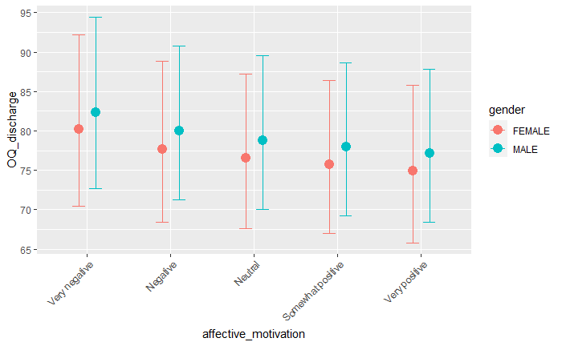

```r
effects_var_int_affective_motivation_gender <-
    conditional_effects(model_var_int,
            effects = "affective_motivation:gender")
plot(effects_var_int_affective_motivation_gender,
     plot = FALSE)[[1]] +
     theme(axis.text.x =
               element_text(angle = 45, vjust = 1, hjust = 1))
```

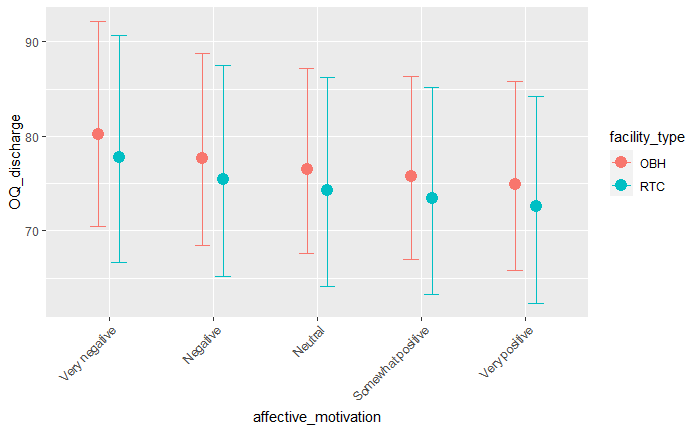

```r
effects_var_int_affective_motivation_fac <-
    conditional_effects(model_var_int,
            effects = "affective_motivation:facility_type")
plot(effects_var_int_affective_motivation_fac,
     plot = FALSE)[[1]] +
     theme(axis.text.x =
               element_text(angle = 45, vjust = 1, hjust = 1))
```

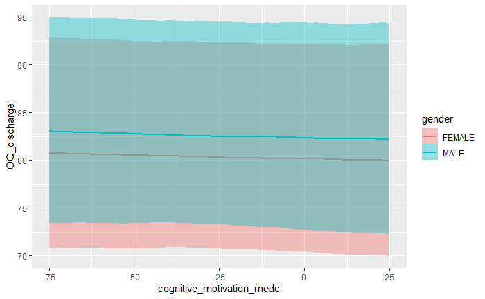

```r
effects_var_int_cognitive_motivation_gender <-
    conditional_effects(model_var_int,
            effects = "cognitive_motivation_medc:gender")
plot(effects_var_int_cognitive_motivation_gender,
     plot = FALSE)[[1]]
```

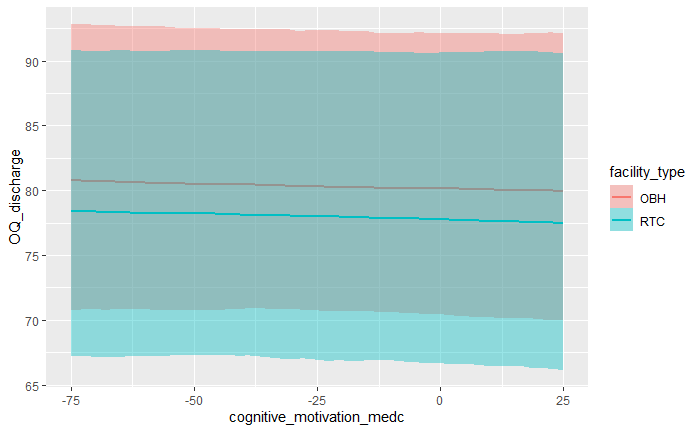

```r
effects_var_int_cognitive_motivation_fac <-
    conditional_effects(model_var_int,
        effects = "cognitive_motivation_medc:facility_type")
plot(effects_var_int_cognitive_motivation_fac,
     plot = FALSE)[[1]]
```

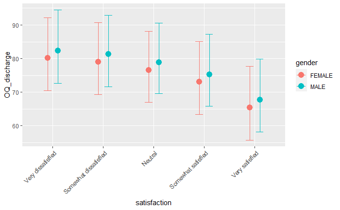

```r
effects_var_int_satisfaction_gender <-
    conditional_effects(model_var_int,
                effects = "satisfaction:gender")
plot(effects_var_int_satisfaction_gender,
     plot = FALSE)[[1]] +
     theme(axis.text.x =
               element_text(angle = 45, vjust = 1, hjust = 1))
```

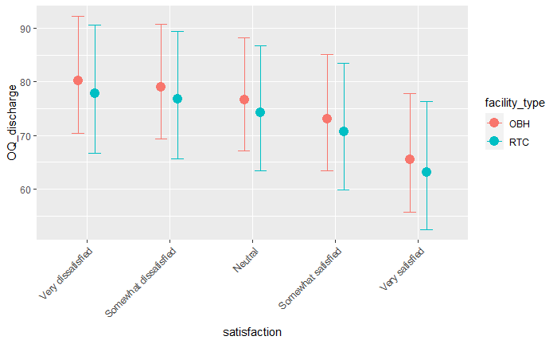

```r
effects_var_int_satisfaction_fac <-
    conditional_effects(model_var_int,
                effects = "satisfaction:facility_type")
plot(effects_var_int_satisfaction_fac,
     plot = FALSE)[[1]] +
     theme(axis.text.x =
               element_text(angle = 45, vjust = 1, hjust = 1))
```

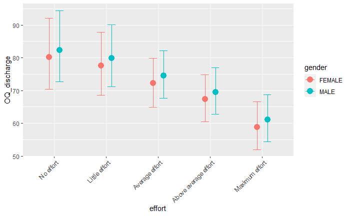

```r
effects_var_int_effort_gender <-
    conditional_effects(model_var_int,
                effects = "effort:gender")
plot(effects_var_int_effort_gender, plot = FALSE)[[1]] +
     theme(axis.text.x =
               element_text(angle = 45, vjust = 1, hjust = 1))
```

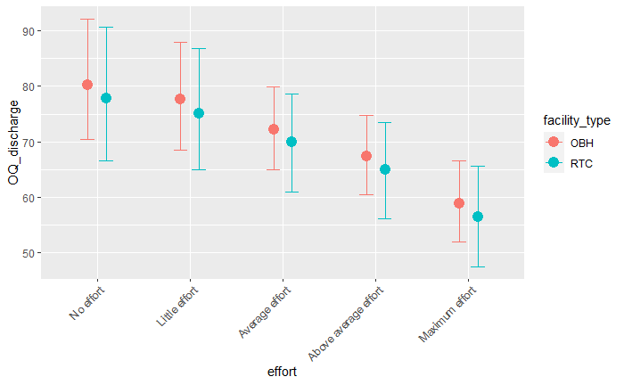

```r
effects_var_int_effort_fac <-
    conditional_effects(model_var_int,
                effects = "effort:facility_type")
plot(effects_var_int_effort_fac, plot = FALSE)[[1]] +
     theme(axis.text.x =
               element_text(angle = 45, vjust = 1, hjust = 1))
```

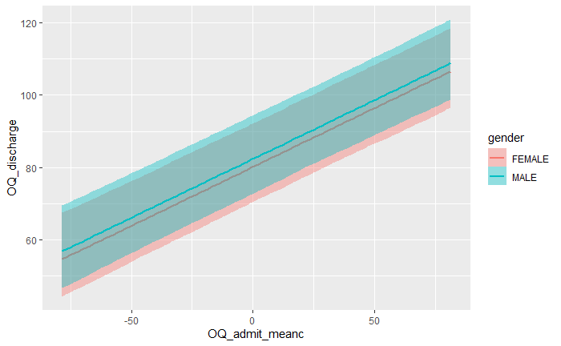

```r
effects_var_int_OQ_admit_gender <-
    conditional_effects(model_var_int,
            effects = "OQ_admit_meanc:gender")
plot(effects_var_int_OQ_admit_gender,
     plot = FALSE)[[1]]
```

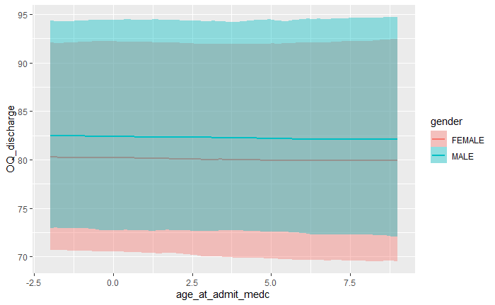

```r
effects_var_int_age_gender <-
    conditional_effects(model_var_int,
            effects = "age_at_admit_medc:gender")
plot(effects_var_int_age_gender,
     plot = FALSE)[[1]]
```

## Extract draws

```r
parnames(model_var_int)
```

```
 [1] "b_Intercept"                     "b_genderMALE"
 [3] "b_OQ_admit_meanc"                "b_age_at_admit_medc"
 [5] "b_facility_typeRTC"              "b_cognitive_motivation_medc"
 [7] "bsp_moaffective_motivation"      "bsp_mosatisfaction"
 [9] "bsp_moeffort"                    "sd_fac_ID__Intercept"
[11] "sigma"                           "simo_moaffective_motivation1[1]"
[13] "simo_moaffective_motivation1[2]" "simo_moaffective_motivation1[3]"
[15] "simo_moaffective_motivation1[4]" "simo_mosatisfaction1[1]"
[17] "simo_mosatisfaction1[2]"         "simo_mosatisfaction1[3]"
[19] "simo_mosatisfaction1[4]"         "simo_moeffort1[1]"
[21] "simo_moeffort1[2]"               "simo_moeffort1[3]"
[23] "simo_moeffort1[4]"               "r_fac_ID[1,Intercept]"
[25] "r_fac_ID[2,Intercept]"           "r_fac_ID[3,Intercept]"
[27] "r_fac_ID[4,Intercept]"           "r_fac_ID[5,Intercept]"
[29] "r_fac_ID[6,Intercept]"           "r_fac_ID[7,Intercept]"
[31] "r_fac_ID[8,Intercept]"           "r_fac_ID[9,Intercept]"
[33] "r_fac_ID[10,Intercept]"          "r_fac_ID[11,Intercept]"
[35] "r_fac_ID[12,Intercept]"          "r_fac_ID[13,Intercept]"
[37] "r_fac_ID[14,Intercept]"          "r_fac_ID[15,Intercept]"
[39] "r_fac_ID[16,Intercept]"          "r_fac_ID[17,Intercept]"
[41] "r_fac_ID[18,Intercept]"          "r_fac_ID[19,Intercept]"
[43] "r_fac_ID[20,Intercept]"          "r_fac_ID[21,Intercept]"
[45] "lp__"
```

```r
draws_p <- model_var_int %>%
    spread_draws(b_Intercept,
                 b_genderMALE,
                 b_OQ_admit_meanc,
                 b_age_at_admit_medc,
                 b_facility_typeRTC,
                 b_cognitive_motivation_medc,
                 bsp_moaffective_motivation,
                 bsp_mosatisfaction,
                 bsp_moeffort,
                 sd_fac_ID__Intercept,
                 sigma)
glimpse(draws_p)
```

```
Rows: 3,000
Columns: 14
$ .chain                      <int> 1, 1, 1, 1, 1, 1, 1, 1, 1, 1, 1, 1, 1, 1, 1, 1,…
$ .iteration                  <int> 1, 2, 3, 4, 5, 6, 7, 8, 9, 10, 11, 12, 13, 14, …
$ .draw                       <int> 1, 2, 3, 4, 5, 6, 7, 8, 9, 10, 11, 12, 13, 14, …
$ b_Intercept                 <dbl> 69.47704, 67.25785, 75.89558, 74.80212, 70.7478…
$ b_genderMALE                <dbl> 2.3157156, 3.4901898, 4.8155628, 0.2546104, 4.5…
$ b_OQ_admit_meanc            <dbl> 0.3177772, 0.3576953, 0.3212765, 0.3424917, 0.2…
$ b_age_at_admit_medc         <dbl> -0.16067120, -0.09765263, -0.25384615, 0.086555…
$ b_facility_typeRTC          <dbl> -0.08238325, -1.95637970, -1.77295397, 0.917693…
$ b_cognitive_motivation_medc <dbl> -0.0247594818, 0.0127202187, -0.0240199991, -0.…
$ bsp_moaffective_motivation  <dbl> -1.02988064, -0.80545884, -0.93914516, -0.83483…
$ bsp_mosatisfaction          <dbl> -3.200248, -2.901928, -3.271803, -3.310942, -3.…
$ bsp_moeffort                <dbl> -3.963912, -3.915160, -5.516620, -5.260222, -4.…
$ sd_fac_ID__Intercept        <dbl> 5.797914, 6.491185, 6.028958, 4.416281, 5.97304…
$ sigma                       <dbl> 18.08657, 18.33388, 18.29955, 18.52145, 18.4387…
```

```r
draws_p_gather <- model_var_int %>%
    gather_draws(b_Intercept,
                 b_genderMALE,
                 b_OQ_admit_meanc,
                 b_age_at_admit_medc,
                 b_facility_typeRTC,
                 b_cognitive_motivation_medc,
                 bsp_moaffective_motivation,
                 bsp_mosatisfaction,
                 bsp_moeffort,
                 sd_fac_ID__Intercept,
                 sigma)
glimpse(draws_p_gather)
```

```
Rows: 33,000
Columns: 5
Groups: .variable [11]
$ .chain     <int> 1, 1, 1, 1, 1, 1, 1, 1, 1, 1, 1, 1, 1, 1, 1, 1, 1, 1, 1, 1, 1, 1…
$ .iteration <int> 1, 2, 3, 4, 5, 6, 7, 8, 9, 10, 11, 12, 13, 14, 15, 16, 17, 18, 1…
$ .draw      <int> 1, 2, 3, 4, 5, 6, 7, 8, 9, 10, 11, 12, 13, 14, 15, 16, 17, 18, 1…
$ .variable  <chr> "b_Intercept", "b_Intercept", "b_Intercept", "b_Intercept", "b_I…
$ .value     <dbl> 69.47704, 67.25785, 75.89558, 74.80212, 70.74787, 68.81388, 72.1…
```

```r
draws_mo <- model_var_int %>%
    spread_draws(simo_moaffective_motivation1[1:4],
                 simo_mosatisfaction1[1:4],
                 simo_moeffort1[1:4])
glimpse(draws_mo)
```

```
Rows: 12,000
Columns: 7
Groups: 1:4 [4]
$ `1:4`                        <int> 1, 1, 1, 1, 1, 1, 1, 1, 1, 1, 1, 1, 1, 1, 1, 1…
$ simo_moaffective_motivation1 <dbl> 0.6153188, 0.5056643, 0.4062665, 0.2835181, 0.…
$ .chain                       <int> 1, 1, 1, 1, 1, 1, 1, 1, 1, 1, 1, 1, 1, 1, 1, 1…
$ .iteration                   <int> 1, 2, 3, 4, 5, 6, 7, 8, 9, 10, 11, 12, 13, 14,…
$ .draw                        <int> 1, 2, 3, 4, 5, 6, 7, 8, 9, 10, 11, 12, 13, 14,…
$ simo_mosatisfaction1         <dbl> 0.0926359512, 0.0259343855, 0.0054818789, 0.00…
$ simo_moeffort1               <dbl> 0.011978453, 0.016197023, 0.359261431, 0.00183…
```

```r
draws_mo_gather <- model_var_int %>%
    gather_draws(simo_moaffective_motivation1[1:4],
                 simo_mosatisfaction1[1:4],
                 simo_moeffort1[1:4])
glimpse(draws_mo_gather)
```

```
Rows: 36,000
Columns: 6
Groups: 1:4, .variable [12]
$ `1:4`      <int> 1, 1, 1, 1, 1, 1, 1, 1, 1, 1, 1, 1, 1, 1, 1, 1, 1, 1, 1, 1, 1, 1…
$ .chain     <int> 1, 1, 1, 1, 1, 1, 1, 1, 1, 1, 1, 1, 1, 1, 1, 1, 1, 1, 1, 1, 1, 1…
$ .iteration <int> 1, 2, 3, 4, 5, 6, 7, 8, 9, 10, 11, 12, 13, 14, 15, 16, 17, 18, 1…
$ .draw      <int> 1, 2, 3, 4, 5, 6, 7, 8, 9, 10, 11, 12, 13, 14, 15, 16, 17, 18, 1…
$ .variable  <chr> "simo_moaffective_motivation1", "simo_moaffective_motivation1", …
$ .value     <dbl> 0.6153188, 0.5056643, 0.4062665, 0.2835181, 0.6563938, 0.5826738…
```

```r
draws_r <- model_var_int %>%
    spread_draws(r_fac_ID[fac_ID, ])
glimpse(draws_r)
```

```
Rows: 63,000
Columns: 5
Groups: fac_ID [21]
$ fac_ID     <int> 1, 1, 1, 1, 1, 1, 1, 1, 1, 1, 1, 1, 1, 1, 1, 1, 1, 1, 1, 1, 1, 1…
$ r_fac_ID   <dbl> 6.78109178, 3.27147425, 3.59367911, 5.04890522, 7.98401301, 7.68…
$ .chain     <int> 1, 1, 1, 1, 1, 1, 1, 1, 1, 1, 1, 1, 1, 1, 1, 1, 1, 1, 1, 1, 1, 1…
$ .iteration <int> 1, 2, 3, 4, 5, 6, 7, 8, 9, 10, 11, 12, 13, 14, 15, 16, 17, 18, 1…
$ .draw      <int> 1, 2, 3, 4, 5, 6, 7, 8, 9, 10, 11, 12, 13, 14, 15, 16, 17, 18, 1…
```

```r
draws_r_gather <- model_var_int %>%
    gather_draws(r_fac_ID[fac_ID, ])
glimpse(draws_r_gather)
```

```
Rows: 63,000
Columns: 6
Groups: fac_ID, .variable [21]
$ fac_ID     <int> 1, 1, 1, 1, 1, 1, 1, 1, 1, 1, 1, 1, 1, 1, 1, 1, 1, 1, 1, 1, 1, 1…
$ .chain     <int> 1, 1, 1, 1, 1, 1, 1, 1, 1, 1, 1, 1, 1, 1, 1, 1, 1, 1, 1, 1, 1, 1…
$ .iteration <int> 1, 2, 3, 4, 5, 6, 7, 8, 9, 10, 11, 12, 13, 14, 15, 16, 17, 18, 1…
$ .draw      <int> 1, 2, 3, 4, 5, 6, 7, 8, 9, 10, 11, 12, 13, 14, 15, 16, 17, 18, 1…
$ .variable  <chr> "r_fac_ID", "r_fac_ID", "r_fac_ID", "r_fac_ID", "r_fac_ID", "r_f…
$ .value     <dbl> 6.78109178, 3.27147425, 3.59367911, 5.04890522, 7.98401301, 7.68…
```

## Posterior summaries

### Population

```r
draws_p %>%
    median_qi()
```

| b_Intercept | b_Intercept.lower | b_Intercept.upper | b_genderMALE | b_genderMALE.lower | b_genderMALE.upper | b_OQ_admit_meanc | b_OQ_admit_meanc.lower | b_OQ_admit_meanc.upper | b_age_at_admit_medc | b_age_at_admit_medc.lower | b_age_at_admit_medc.upper | b_facility_typeRTC | b_facility_typeRTC.lower | b_facility_typeRTC.upper | b_cognitive_motivation_medc | b_cognitive_motivation_medc.lower | b_cognitive_motivation_medc.upper | bsp_moaffective_motivation | bsp_moaffective_motivation.lower | bsp_moaffective_motivation.upper | bsp_mosatisfaction | bsp_mosatisfaction.lower | bsp_mosatisfaction.upper | bsp_moeffort | bsp_moeffort.lower | bsp_moeffort.upper | sd_fac_ID__Intercept | sd_fac_ID__Intercept.lower | sd_fac_ID__Intercept.upper | … |
| --- | --- | --- | --- | --- | --- | --- | --- | --- | --- | --- | --- | --- | --- | --- | --- | --- | --- | --- | --- | --- | --- | --- | --- | --- | --- | --- | --- | --- | --- | --- |
| 80.19105 | 70.49609 | 92.26567 | 2.252061 | -0.01023146 | 4.518937 | 0.3242959 | 0.2824874 | 0.3662553 | -0.04256934 | -0.4315704 | 0.376837 | -2.303413 | -10.08142 | 4.379376 | -0.006947527 | -0.05742853 | 0.04088597 | -1.269836 | -2.787213 | -0.04309061 | -3.629822 | -4.787642 | -2.574844 | -5.261637 | -7.810525 | -3.486046 | 5.431149 | 3.285832 | 9.37767 | … |

```r
draws_p_gather %>%
    median_qi()
```

| .variable | .value | .lower | .upper | .width | .point | .interval |
| --- | --- | --- | --- | --- | --- | --- |
| b_age_at_admit_medc | -0.042569338 | -0.43157036 | 0.37683704 | 0.95 | median | qi |
| b_cognitive_motivation_medc | -0.006947527 | -0.05742853 | 0.04088597 | 0.95 | median | qi |
| b_facility_typeRTC | -2.303413293 | -10.08142284 | 4.37937590 | 0.95 | median | qi |
| b_genderMALE | 2.252060513 | -0.01023146 | 4.51893681 | 0.95 | median | qi |
| b_Intercept | 80.191050737 | 70.49609053 | 92.26567167 | 0.95 | median | qi |
| b_OQ_admit_meanc | 0.324295945 | 0.28248737 | 0.36625533 | 0.95 | median | qi |
| bsp_moaffective_motivation | -1.269836461 | -2.78721337 | -0.04309061 | 0.95 | median | qi |
| bsp_moeffort | -5.261636622 | -7.81052482 | -3.48604646 | 0.95 | median | qi |
| bsp_mosatisfaction | -3.629822422 | -4.78764158 | -2.57484356 | 0.95 | median | qi |
| sd_fac_ID__Intercept | 5.431149492 | 3.28583209 | 9.37766994 | 0.95 | median | qi |

[output cut: 1 more lines]

### Monotonic ordinal

```r
draws_mo %>%
    median_qi()
```

| 1:4 | simo_moaffective_motivation1 | simo_moaffective_motivation1.lower | simo_moaffective_motivation1.upper | simo_mosatisfaction1 | simo_mosatisfaction1.lower | simo_mosatisfaction1.upper | simo_moeffort1 | simo_moeffort1.lower | simo_moeffort1.upper | .width | .point | .interval |
| --- | --- | --- | --- | --- | --- | --- | --- | --- | --- | --- | --- | --- |
| 1 | 0.4022761 | 0.027320405 | 0.8059915 | 0.05653769 | 0.001820456 | 0.2434483 | 0.09396275 | 0.003510424 | 0.3647004 | 0.95 | median | qi |
| 2 | 0.1984047 | 0.007201575 | 0.6466222 | 0.14238322 | 0.008995545 | 0.4111262 | 0.23207594 | 0.016564828 | 0.5092050 | 0.95 | median | qi |
| 3 | 0.1436195 | 0.006634464 | 0.5644914 | 0.23227960 | 0.023502613 | 0.4941305 | 0.23382964 | 0.074052358 | 0.4230361 | 0.95 | median | qi |
| 4 | 0.1536207 | 0.008562801 | 0.5685153 | 0.52003399 | 0.325007999 | 0.7544266 | 0.39573060 | 0.250791716 | 0.6083319 | 0.95 | median | qi |

```r
draws_mo_gather %>%
    median_qi()
```

| 1:4 | .variable | .value | .lower | .upper | .width | .point | .interval |
| --- | --- | --- | --- | --- | --- | --- | --- |
| 1 | simo_moaffective_motivation1 | 0.40227615 | 0.027320405 | 0.8059915 | 0.95 | median | qi |
| 1 | simo_moeffort1 | 0.09396275 | 0.003510424 | 0.3647004 | 0.95 | median | qi |
| 1 | simo_mosatisfaction1 | 0.05653769 | 0.001820456 | 0.2434483 | 0.95 | median | qi |
| 2 | simo_moaffective_motivation1 | 0.19840470 | 0.007201575 | 0.6466222 | 0.95 | median | qi |
| 2 | simo_moeffort1 | 0.23207594 | 0.016564828 | 0.5092050 | 0.95 | median | qi |
| 2 | simo_mosatisfaction1 | 0.14238322 | 0.008995545 | 0.4111262 | 0.95 | median | qi |
| 3 | simo_moaffective_motivation1 | 0.14361954 | 0.006634464 | 0.5644914 | 0.95 | median | qi |
| 3 | simo_moeffort1 | 0.23382964 | 0.074052358 | 0.4230361 | 0.95 | median | qi |
| 3 | simo_mosatisfaction1 | 0.23227960 | 0.023502613 | 0.4941305 | 0.95 | median | qi |
| 4 | simo_moaffective_motivation1 | 0.15362070 | 0.008562801 | 0.5685153 | 0.95 | median | qi |

[output cut: 2 more lines]

BUT, medians will not add up to 100%. That’s why we need means for the simo parameters:

```r
draws_mo %>%
    mean_qi()
```

| 1:4 | simo_moaffective_motivation1 | simo_moaffective_motivation1.lower | simo_moaffective_motivation1.upper | simo_mosatisfaction1 | simo_mosatisfaction1.lower | simo_mosatisfaction1.upper | simo_moeffort1 | simo_moeffort1.lower | simo_moeffort1.upper | .width | .point | .interval |
| --- | --- | --- | --- | --- | --- | --- | --- | --- | --- | --- | --- | --- |
| 1 | 0.4043292 | 0.027320405 | 0.8059915 | 0.07413665 | 0.001820456 | 0.2434483 | 0.1179001 | 0.003510424 | 0.3647004 | 0.95 | mean | qi |
| 2 | 0.2324246 | 0.007201575 | 0.6466222 | 0.16286820 | 0.008995545 | 0.4111262 | 0.2386466 | 0.016564828 | 0.5092050 | 0.95 | mean | qi |
| 3 | 0.1769129 | 0.006634464 | 0.5644914 | 0.23741750 | 0.023502613 | 0.4941305 | 0.2376664 | 0.074052358 | 0.4230361 | 0.95 | mean | qi |
| 4 | 0.1863334 | 0.008562801 | 0.5685153 | 0.52557765 | 0.325007999 | 0.7544266 | 0.4057869 | 0.250791716 | 0.6083319 | 0.95 | mean | qi |

```r
draws_mo_gather %>%
    mean_qi()
```

| 1:4 | .variable | .value | .lower | .upper | .width | .point | .interval |
| --- | --- | --- | --- | --- | --- | --- | --- |
| 1 | simo_moaffective_motivation1 | 0.40432917 | 0.027320405 | 0.8059915 | 0.95 | mean | qi |
| 1 | simo_moeffort1 | 0.11790015 | 0.003510424 | 0.3647004 | 0.95 | mean | qi |
| 1 | simo_mosatisfaction1 | 0.07413665 | 0.001820456 | 0.2434483 | 0.95 | mean | qi |
| 2 | simo_moaffective_motivation1 | 0.23242456 | 0.007201575 | 0.6466222 | 0.95 | mean | qi |
| 2 | simo_moeffort1 | 0.23864660 | 0.016564828 | 0.5092050 | 0.95 | mean | qi |
| 2 | simo_mosatisfaction1 | 0.16286820 | 0.008995545 | 0.4111262 | 0.95 | mean | qi |
| 3 | simo_moaffective_motivation1 | 0.17691289 | 0.006634464 | 0.5644914 | 0.95 | mean | qi |
| 3 | simo_moeffort1 | 0.23766637 | 0.074052358 | 0.4230361 | 0.95 | mean | qi |
| 3 | simo_mosatisfaction1 | 0.23741750 | 0.023502613 | 0.4941305 | 0.95 | mean | qi |
| 4 | simo_moaffective_motivation1 | 0.18633339 | 0.008562801 | 0.5685153 | 0.95 | mean | qi |

[output cut: 2 more lines]

### Random effects

```r
draws_r %>%
    median_qi()
```

| fac_ID | r_fac_ID | .lower | .upper | .width | .point | .interval |
| --- | --- | --- | --- | --- | --- | --- |
| 1 | 2.8342118 | -1.85431072 | 7.6215794 | 0.95 | median | qi |
| 2 | 4.7442292 | 0.07765905 | 9.5180834 | 0.95 | median | qi |
| 3 | -4.8430075 | -10.50532728 | 0.5278687 | 0.95 | median | qi |
| 4 | -1.1650277 | -5.28225656 | 3.2373850 | 0.95 | median | qi |
| 5 | -4.7575761 | -12.50037028 | 2.7065529 | 0.95 | median | qi |
| 6 | 8.2460645 | 0.41313234 | 18.2946143 | 0.95 | median | qi |
| 7 | 3.0308353 | -2.37985735 | 8.6892178 | 0.95 | median | qi |
| 8 | 2.6435416 | -4.91149776 | 10.9768509 | 0.95 | median | qi |
| 9 | 2.0399336 | -4.72638162 | 9.8739493 | 0.95 | median | qi |
| 10 | -0.5500610 | -10.26839248 | 9.0223750 | 0.95 | median | qi |

[output cut: 11 more lines]

```r
draws_r_gather %>%
    median_qi()
```

| fac_ID | .variable | .value | .lower | .upper | .width | .point | .interval |
| --- | --- | --- | --- | --- | --- | --- | --- |
| 1 | r_fac_ID | 2.8342118 | -1.85431072 | 7.6215794 | 0.95 | median | qi |
| 2 | r_fac_ID | 4.7442292 | 0.07765905 | 9.5180834 | 0.95 | median | qi |
| 3 | r_fac_ID | -4.8430075 | -10.50532728 | 0.5278687 | 0.95 | median | qi |
| 4 | r_fac_ID | -1.1650277 | -5.28225656 | 3.2373850 | 0.95 | median | qi |
| 5 | r_fac_ID | -4.7575761 | -12.50037028 | 2.7065529 | 0.95 | median | qi |
| 6 | r_fac_ID | 8.2460645 | 0.41313234 | 18.2946143 | 0.95 | median | qi |
| 7 | r_fac_ID | 3.0308353 | -2.37985735 | 8.6892178 | 0.95 | median | qi |
| 8 | r_fac_ID | 2.6435416 | -4.91149776 | 10.9768509 | 0.95 | median | qi |
| 9 | r_fac_ID | 2.0399336 | -4.72638162 | 9.8739493 | 0.95 | median | qi |
| 10 | r_fac_ID | -0.5500610 | -10.26839248 | 9.0223750 | 0.95 | median | qi |

[output cut: 11 more lines]

## Posterior graphs

Simplify theme:

```r
theme_set(theme_tidybayes() + panel_border())
```

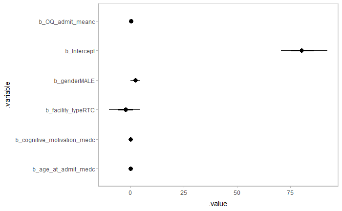

```r
draws_p_gather %>%
    filter(str_detect(.variable, "^b_")) %>%
    ggplot(aes(y = .variable, x = .value)) +
    stat_pointinterval()
```

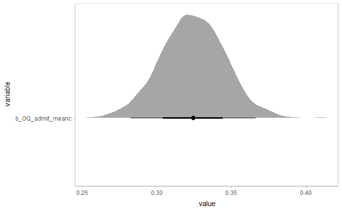

```r
draws_p_gather %>%
    filter(.variable == "b_OQ_admit_meanc") %>%
    ggplot(aes(y = .variable, x = .value)) +
    stat_halfeye()
```

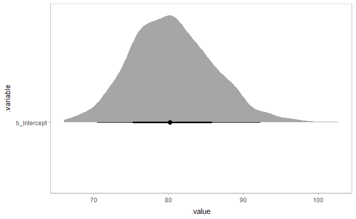

```r
draws_p_gather %>%
    filter(.variable == "b_Intercept") %>%
    ggplot(aes(y = .variable, x = .value)) +
    stat_halfeye()
```

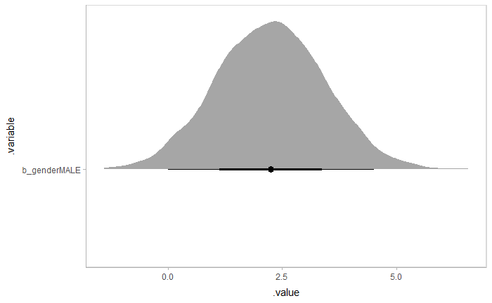

```r
draws_p_gather %>%
    filter(.variable == "b_genderMALE") %>%
    ggplot(aes(y = .variable, x = .value)) +
    stat_halfeye()
```

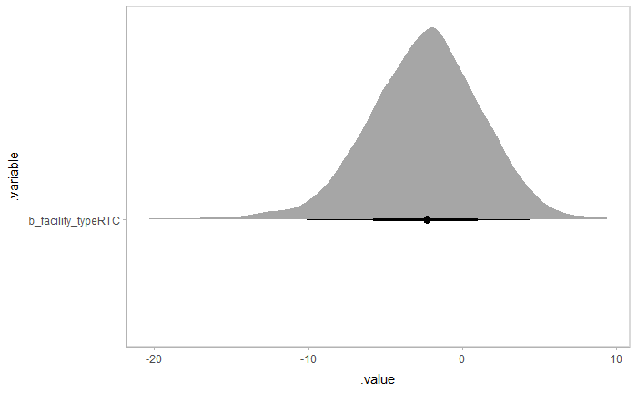

```r
draws_p_gather %>%
    filter(.variable == "b_facility_typeRTC") %>%
    ggplot(aes(y = .variable, x = .value)) +
    stat_halfeye()
```

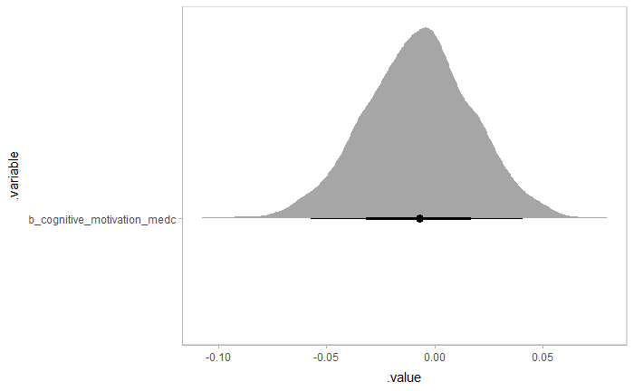

```r
draws_p_gather %>%
    filter(.variable == "b_cognitive_motivation_medc") %>%
    ggplot(aes(y = .variable, x = .value)) +
    stat_halfeye()
```

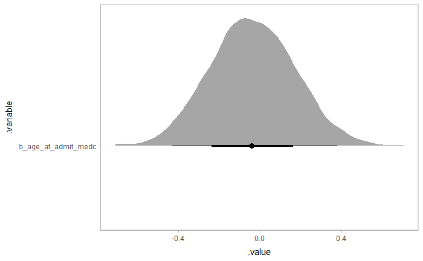

```r
draws_p_gather %>%
    filter(.variable == "b_age_at_admit_medc") %>%
    ggplot(aes(y = .variable, x = .value)) +
    stat_halfeye()
```

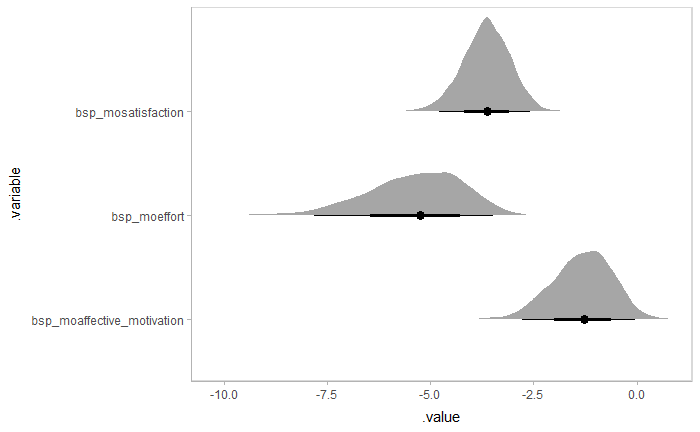

```r
draws_p_gather %>%
    filter(str_detect(.variable, "^bsp_")) %>%
    ggplot(aes(y = .variable, x = .value)) +
    stat_halfeye()
```

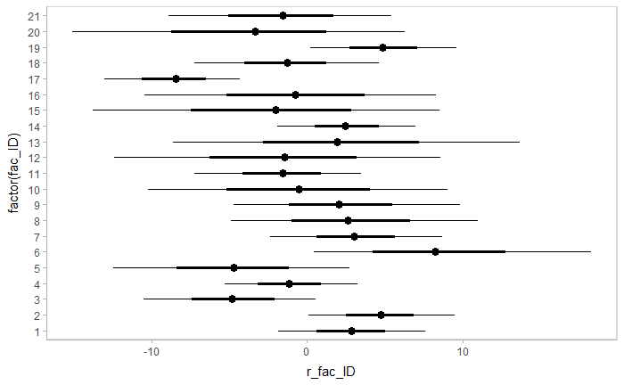

```r
draws_r %>%
    ggplot(aes(y = factor(fac_ID), x = r_fac_ID)) +
    stat_pointinterval()
```

## Posteriors for ordinal predictors

### Get all ordinal parts into one data frame

```r
draws_mo_unspread <- draws_mo %>%
    unspread_draws(simo_moaffective_motivation1[1:4],
                   simo_mosatisfaction1[1:4],
                   simo_moeffort1[1:4])
str(draws_mo_unspread)
```

```
tibble [3,000 × 15] (S3: tbl_df/tbl/data.frame)
 $ .chain                         : int [1:3000] 1 1 1 1 1 1 1 1 1 1 ...
 $ .iteration                     : int [1:3000] 1 2 3 4 5 6 7 8 9 10 ...
 $ .draw                          : int [1:3000] 1 2 3 4 5 6 7 8 9 10 ...
 $ simo_moaffective_motivation1[1]: num [1:3000] 0.615 0.506 0.406 0.284 0.656 ...
 $ simo_moaffective_motivation1[2]: num [1:3000] 0.1775 0.0508 0.0623 0.4342 0.0925 ...
 $ simo_moaffective_motivation1[3]: num [1:3000] 0.157 0.1197 0.3985 0.0843 0.0553 ...
 $ simo_moaffective_motivation1[4]: num [1:3000] 0.0502 0.3238 0.1329 0.198 0.1959 ...
 $ simo_mosatisfaction1[1]        : num [1:3000] 0.092636 0.025934 0.005482 0.000689 0.064957 ...
 $ simo_mosatisfaction1[2]        : num [1:3000] 0.0575 0.0365 0.241 0.0187 0.2146 ...
 $ simo_mosatisfaction1[3]        : num [1:3000] 0.254 0.281 0.352 0.384 0.247 ...
 $ simo_mosatisfaction1[4]        : num [1:3000] 0.596 0.657 0.401 0.597 0.473 ...
 $ simo_moeffort1[1]              : num [1:3000] 0.01198 0.0162 0.35926 0.00184 0.00649 ...
 $ simo_moeffort1[2]              : num [1:3000] 0.1344 0.1481 0.0743 0.2963 0.1386 ...
 $ simo_moeffort1[3]              : num [1:3000] 0.273 0.403 0.204 0.258 0.337 ...
 $ simo_moeffort1[4]              : num [1:3000] 0.581 0.433 0.363 0.444 0.518 ...
```

```r
draws_bsp <- draws_p %>%
    select(starts_with("bsp_"), starts_with("."))
str(draws_bsp)
```

```
tibble [3,000 × 6] (S3: tbl_df/tbl/data.frame)
 $ bsp_moaffective_motivation: num [1:3000] -1.03 -0.805 -0.939 -0.835 -2.386 ...
 $ bsp_mosatisfaction        : num [1:3000] -3.2 -2.9 -3.27 -3.31 -3.14 ...
 $ bsp_moeffort              : num [1:3000] -3.96 -3.92 -5.52 -5.26 -4.24 ...
 $ .chain                    : int [1:3000] 1 1 1 1 1 1 1 1 1 1 ...
 $ .iteration                : int [1:3000] 1 2 3 4 5 6 7 8 9 10 ...
 $ .draw                     : int [1:3000] 1 2 3 4 5 6 7 8 9 10 ...
```

```r
draws_mo_all <- inner_join(draws_bsp, draws_mo_unspread,
                           by = ".draw") %>%
    select(-ends_with(".x")) %>%
    select(-ends_with(".y")) %>%
    mutate(affective_motivation_cum1 =
               bsp_moaffective_motivation * 4 *
               `simo_moaffective_motivation1[1]`,
           affective_motivation_cum2 =
               affective_motivation_cum1 +
               bsp_moaffective_motivation * 4 *
               `simo_moaffective_motivation1[2]`,
           affective_motivation_cum3 =
               affective_motivation_cum2 +
               bsp_moaffective_motivation * 4 *
               `simo_moaffective_motivation1[3]`,
           affective_motivation_cum4 =
               affective_motivation_cum3 +
               bsp_moaffective_motivation * 4 *
               `simo_moaffective_motivation1[4]`,
           satisfaction_cum1 =
               bsp_mosatisfaction * 4 *
               `simo_mosatisfaction1[1]`,
           satisfaction_cum2 =
               satisfaction_cum1 +
               bsp_mosatisfaction * 4 *
               `simo_mosatisfaction1[2]`,
           satisfaction_cum3 =
               satisfaction_cum2 +
               bsp_mosatisfaction * 4 *
               `simo_mosatisfaction1[3]`,
           satisfaction_cum4 =
               satisfaction_cum3 +
               bsp_mosatisfaction * 4 *
               `simo_mosatisfaction1[4]`,
           effort_cum1 =
               bsp_moeffort * 4 *
               `simo_moeffort1[1]`,
           effort_cum2 =
               effort_cum1 +
               bsp_moeffort * 4 *
               `simo_moeffort1[2]`,
           effort_cum3 =
               effort_cum2 +
               bsp_moeffort * 4 *
               `simo_moeffort1[3]`,
           effort_cum4 =
               effort_cum3 +
               bsp_moeffort * 4 *
               `simo_moeffort1[4]`,)
glimpse(draws_mo_all)
```

```
Rows: 3,000
Columns: 28
$ bsp_moaffective_motivation        <dbl> -1.02988064, -0.80545884, -0.93914516, -0…
$ bsp_mosatisfaction                <dbl> -3.200248, -2.901928, -3.271803, -3.31094…
$ bsp_moeffort                      <dbl> -3.963912, -3.915160, -5.516620, -5.26022…
$ .draw                             <int> 1, 2, 3, 4, 5, 6, 7, 8, 9, 10, 11, 12, 13…
$ `simo_moaffective_motivation1[1]` <dbl> 0.6153188, 0.5056643, 0.4062665, 0.283518…
$ `simo_moaffective_motivation1[2]` <dbl> 0.17748637, 0.05079080, 0.06232436, 0.434…
$ `simo_moaffective_motivation1[3]` <dbl> 0.15703968, 0.11974631, 0.39851673, 0.084…
$ `simo_moaffective_motivation1[4]` <dbl> 0.05015512, 0.32379855, 0.13289240, 0.197…
$ `simo_mosatisfaction1[1]`         <dbl> 0.0926359512, 0.0259343855, 0.0054818789,…
$ `simo_mosatisfaction1[2]`         <dbl> 0.05751928, 0.03646947, 0.24101020, 0.018…
$ `simo_mosatisfaction1[3]`         <dbl> 0.254134740, 0.280970934, 0.352248814, 0.…
$ `simo_mosatisfaction1[4]`         <dbl> 0.5957100, 0.6566252, 0.4012591, 0.596812…
$ `simo_moeffort1[1]`               <dbl> 0.011978453, 0.016197023, 0.359261431, 0.…
$ `simo_moeffort1[2]`               <dbl> 0.134354070, 0.148055293, 0.074299404, 0.…
$ `simo_moeffort1[3]`               <dbl> 0.2726885, 0.4026868, 0.2038381, 0.257890…
$ `simo_moeffort1[4]`               <dbl> 0.5809790, 0.4330608, 0.3626010, 0.443977…
$ affective_motivation_cum1         <dbl> -2.53481974, -1.62916724, -1.52617293, -0…
$ affective_motivation_cum2         <dbl> -3.2659789, -1.7928068, -1.7602994, -2.39…
$ affective_motivation_cum3         <dbl> -3.9129074, -2.1786097, -3.2573596, -2.67…
$ affective_motivation_cum4         <dbl> -4.1195225, -3.2218354, -3.7565807, -3.33…
$ satisfaction_cum1                 <dbl> -1.185831949, -0.301038899, -0.071742503,…
$ satisfaction_cum2                 <dbl> -1.9221357, -0.7243660, -3.2258938, -0.25…
$ satisfaction_cum3                 <dbl> -5.175312, -3.985796, -7.835848, -5.33972…
$ satisfaction_cum4                 <dbl> -12.80099, -11.60771, -13.08721, -13.2437…
$ effort_cum1                       <dbl> -0.18992611, -0.25365573, -7.92763523, -0…
$ effort_cum2                       <dbl> -2.3201967, -2.5722962, -9.5671615, -6.27…
$ effort_cum3                       <dbl> -6.643849, -8.878629, -14.065152, -11.699…
$ effort_cum4                       <dbl> -15.85565, -15.66064, -22.06648, -21.0408…
```

### Summarize and plot

```r
draws_mo_all[1,]
```

| bsp_moaffective_motivation | bsp_mosatisfaction | bsp_moeffort | .draw | simo_moaffective_motivation1[1] | simo_moaffective_motivation1[2] | simo_moaffective_motivation1[3] | simo_moaffective_motivation1[4] | simo_mosatisfaction1[1] | simo_mosatisfaction1[2] | simo_mosatisfaction1[3] | simo_mosatisfaction1[4] | simo_moeffort1[1] | simo_moeffort1[2] | simo_moeffort1[3] | simo_moeffort1[4] | affective_motivation_cum1 | affective_motivation_cum2 | affective_motivation_cum3 | affective_motivation_cum4 | satisfaction_cum1 | satisfaction_cum2 | satisfaction_cum3 | satisfaction_cum4 | effort_cum1 | effort_cum2 | effort_cum3 | effort_cum4 |
| --- | --- | --- | --- | --- | --- | --- | --- | --- | --- | --- | --- | --- | --- | --- | --- | --- | --- | --- | --- | --- | --- | --- | --- | --- | --- | --- | --- |
| -1.029881 | -3.200248 | -3.963912 | 1 | 0.6153188 | 0.1774864 | 0.1570397 | 0.05015512 | 0.09263595 | 0.05751928 | 0.2541347 | 0.59571 | 0.01197845 | 0.1343541 | 0.2726885 | 0.580979 | -2.53482 | -3.265979 | -3.912907 | -4.119523 | -1.185832 | -1.922136 | -5.175312 | -12.80099 | -0.1899261 | -2.320197 | -6.643849 | -15.85565 |

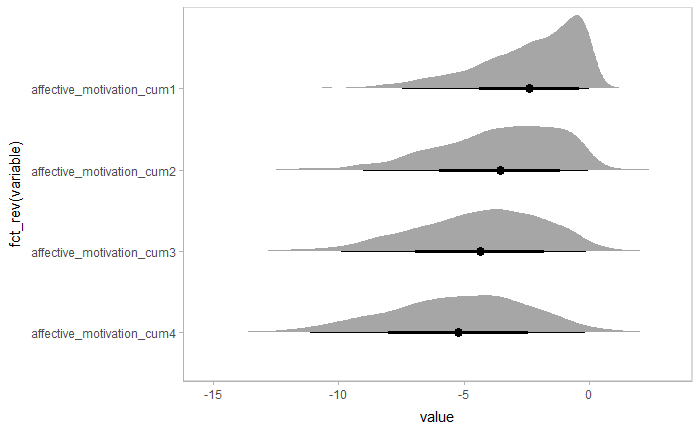

```r
draws_mo_all %>%
    select(starts_with("aff")) %>%
    pivot_longer(starts_with("aff"),
                 names_to = "variable") %>%
    ggplot(aes(y = fct_rev(variable), x = value)) +
    stat_halfeye(point_interval = mean_qi)
```

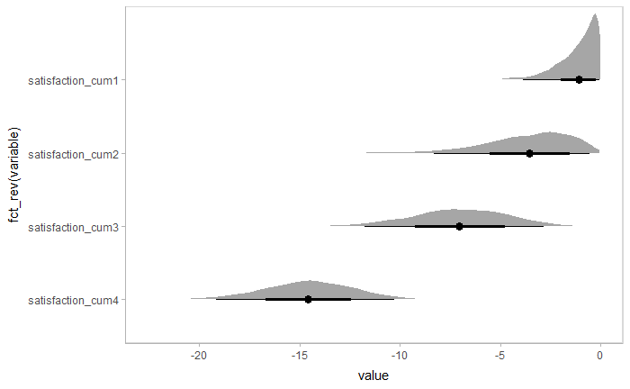

```r
draws_mo_all %>%
    select(starts_with("sat")) %>%
    pivot_longer(starts_with("sat"),
                 names_to = "variable") %>%
    ggplot(aes(y = fct_rev(variable), x = value)) +
    stat_halfeye(point_interval = mean_qi)
```

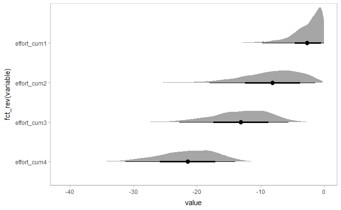

```r
draws_mo_all %>%
    select(starts_with("eff")) %>%
    pivot_longer(starts_with("eff"),
                 names_to = "variable") %>%
    ggplot(aes(y = fct_rev(variable), x = value)) +
    stat_halfeye(point_interval = mean_qi)
```

# Final graphs for publication

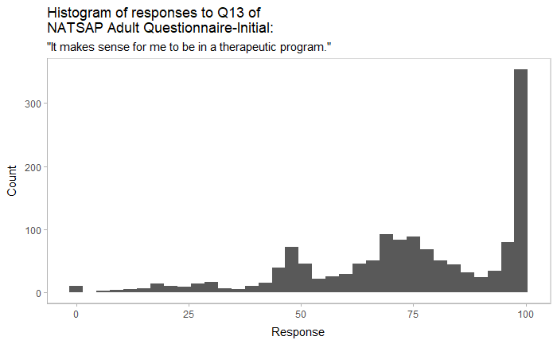

```r
Q13_plot <- ggplot(YA, aes(x = cognitive_motivation)) +
    geom_histogram(binwidth = 3) +
    labs(title = "Histogram of responses to Q13 of
NATSAP Adult Questionnaire-Initial:",
        subtitle = "\"It makes sense for me to be in a therapeutic program.\"",
        y = "Count",
        x = "Response")
Q13_plot
```

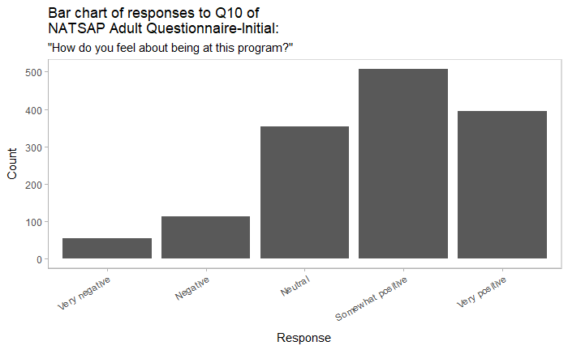

```r
Q10_plot <- ggplot(YA, aes(x = affective_motivation)) +
    geom_bar() +
    labs(title = "Bar chart of responses to Q10 of
NATSAP Adult Questionnaire-Initial:",
        subtitle = "\"How do you feel about being at this program?\"",
        y = "Count",
        x = "Response") +
     theme(axis.text.x =
               element_text(angle = 30, vjust = 1, hjust = 1))
Q10_plot
```

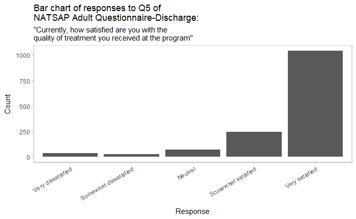

```r
Q5_plot <- ggplot(YA, aes(x = satisfaction)) +
    geom_bar() +
    labs(title = "Bar chart of responses to Q5 of
NATSAP Adult Questionnaire-Discharge:",
        subtitle = "\"Currently, how satisfied are you with the
quality of treatment you received at the program\"",
        y = "Count",
        x = "Response") +
     theme(axis.text.x =
               element_text(angle = 30, vjust = 1, hjust = 1))
Q5_plot
```

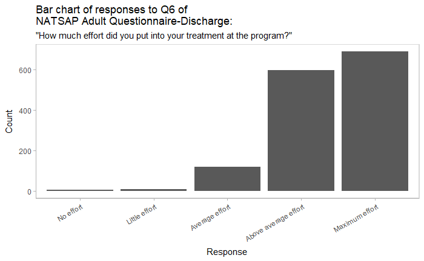

```r
Q6_plot <- ggplot(YA, aes(x = effort)) +
    geom_bar() +
    labs(title = "Bar chart of responses to Q6 of
NATSAP Adult Questionnaire-Discharge:",
        subtitle = "\"How much effort did you put into your treatment at the program?\"",
        y = "Count",
        x = "Response") +
     theme(axis.text.x =
               element_text(angle = 30, vjust = 1, hjust = 1))
Q6_plot
```

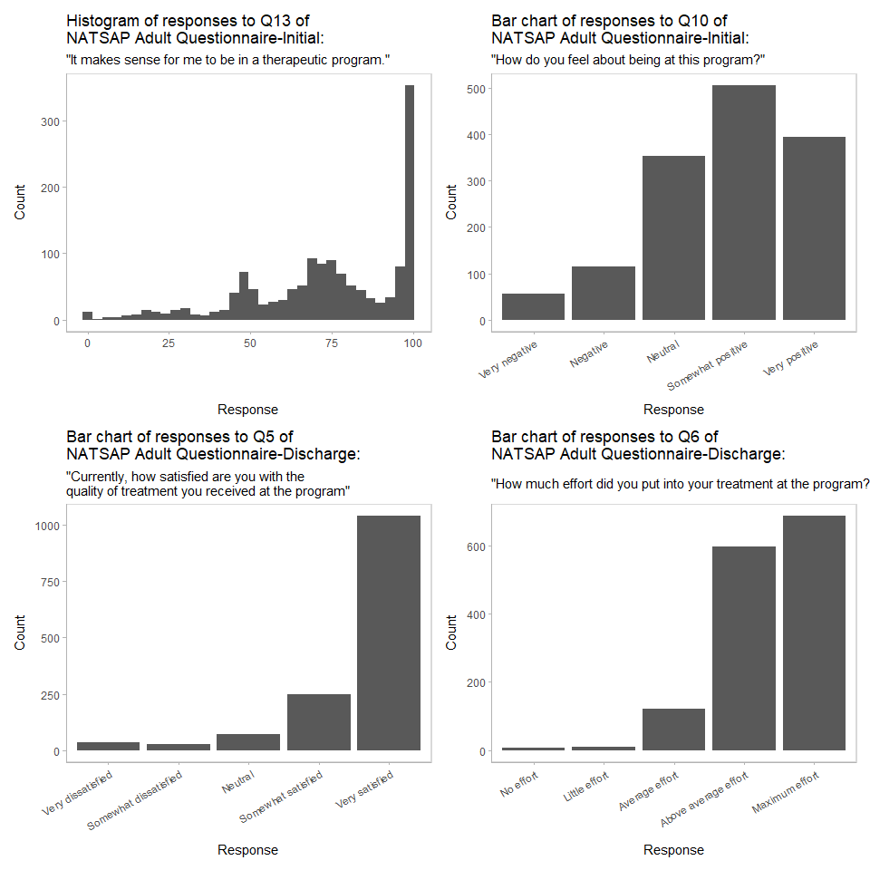

```r
wrap_plots(Q13_plot, Q10_plot, Q5_plot, Q6_plot)
```

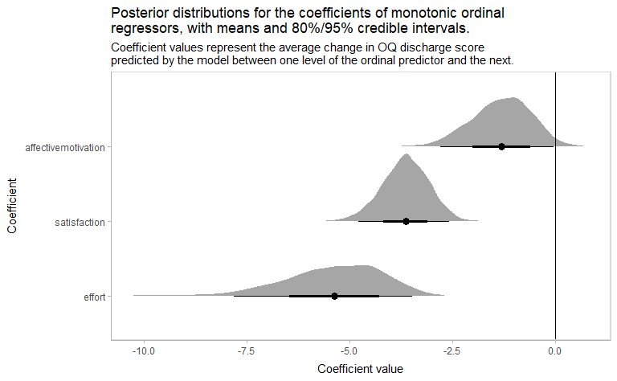

```r
draws_p_gather %>%
    filter(str_detect(.variable, "^bsp_")) %>%
    mutate(.variable = factor(.variable, levels = c("bsp_moeffort",
                                                    "bsp_mosatisfaction",
                                                    "bsp_moaffective_motivation"))) %>%
    ggplot(aes(y = .variable, x = .value)) +
    stat_halfeye(point_interval = mean_qi) +
    labs(title = "Posterior distributions for the coefficients of monotonic ordinal
regressors, with means and 80%/95% credible intervals.",
         subtitle = "Coefficient values represent the average change in OQ discharge score
predicted by the model between one level of the ordinal predictor and the next.",
         y = "Coefficient",
         x = "Coefficient value") +
    scale_y_discrete(labels = c("effort",
                                "satisfaction",
                                "affectivemotivation")) +
    geom_vline(xintercept = 0)
```

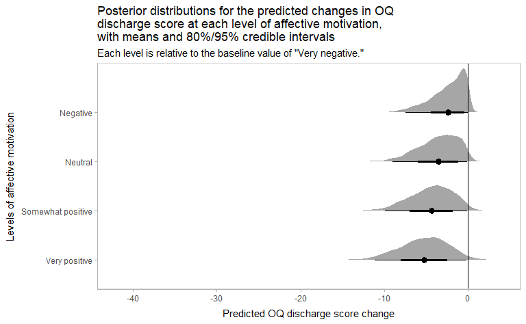

```r
draws_mo_all %>%
    select(starts_with("aff")) %>%
    pivot_longer(starts_with("aff"),
                 names_to = "variable") %>%
    ggplot(aes(y = fct_rev(variable), x = value)) +
    stat_halfeye(point_interval = mean_qi) +
    labs(title = "Posterior distributions for the predicted changes in OQ
discharge score at each level of affective motivation,
with means and 80%/95% credible intervals",
        subtitle = "Each level is relative to the baseline value of \"Very negative.\"",
         y = "Levels of affective motivation",
         x = "Predicted OQ discharge score change") +
    scale_y_discrete(labels = c("Very positive",
                                "Somewhat positive",
                                "Neutral",
                                "Negative")) +
    lims(x = c(-42, 4)) +
    geom_vline(xintercept = 0)
```

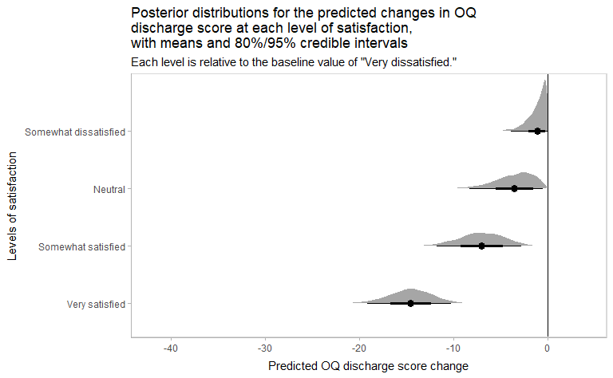

```r
draws_mo_all %>%
    select(starts_with("sat")) %>%
    pivot_longer(starts_with("sat"),
                 names_to = "variable") %>%
    ggplot(aes(y = fct_rev(variable), x = value)) +
    stat_halfeye(point_interval = mean_qi) +
    labs(title = "Posterior distributions for the predicted changes in OQ
discharge score at each level of satisfaction,
with means and 80%/95% credible intervals",
        subtitle = "Each level is relative to the baseline value of \"Very dissatisfied.\"",
         y = "Levels of satisfaction",
         x = "Predicted OQ discharge score change") +
    scale_y_discrete(labels = c("Very satisfied",
                                "Somewhat satisfied",
                                "Neutral",
                                "Somewhat dissatisfied")) +
    lims(x = c(-42, 4)) +
    geom_vline(xintercept = 0)
```

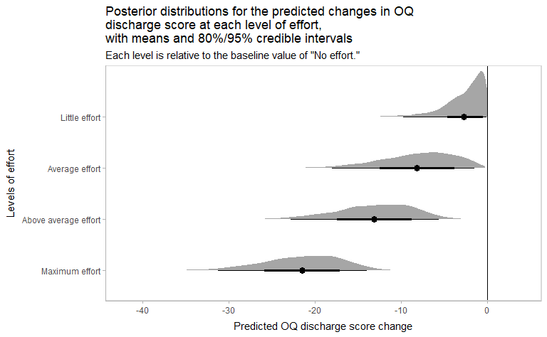

```r
draws_mo_all %>%
    select(starts_with("eff")) %>%
    pivot_longer(starts_with("eff"),
                 names_to = "variable") %>%
    ggplot(aes(y = fct_rev(variable), x = value)) +
    stat_halfeye(point_interval = mean_qi) +
    labs(title = "Posterior distributions for the predicted changes in OQ
discharge score at each level of effort,
with means and 80%/95% credible intervals",
        subtitle = "Each level is relative to the baseline value of \"No effort.\"",
         y = "Levels of effort",
         x = "Predicted OQ discharge score change") +
    scale_y_discrete(labels = c("Maximum effort",
                                "Above average effort",
                                "Average effort",
                                "Little effort")) +
    lims(x = c(-42, 4)) +
    geom_vline(xintercept = 0)
```

# Tables (not formatted yet)

All model coefficients:

```r
summary(model_var_int, priors = TRUE)
```

```
 Family: gaussian
  Links: mu = identity; sigma = identity
Formula: OQ_discharge ~ 1 + (1 | fac_ID) + gender + OQ_admit_meanc + age_at_admit_medc + facility_type + mo(affective_motivation) + cognitive_motivation_medc + mo(satisfaction) + mo(effort)
   Data: YA (Number of observations: 1423)
  Draws: 3 chains, each with iter = 2000; warmup = 1000; thin = 1;
         total post-warmup draws = 3000

Priors:
Intercept ~ student_t(3, 48, 22.2)
<lower=0> sd ~ student_t(3, 0, 22.2)
<lower=0> sigma ~ student_t(3, 0, 22.2)

Group-Level Effects:
~fac_ID (Number of levels: 21)
              Estimate Est.Error l-95% CI u-95% CI Rhat Bulk_ESS Tail_ESS
sd(Intercept)     5.68      1.55     3.29     9.38 1.00     1014     1821

Population-Level Effects:
                          Estimate Est.Error l-95% CI u-95% CI Rhat Bulk_ESS
Intercept                    80.47      5.52    70.50    92.27 1.00     1258
genderMALE                    2.24      1.17    -0.01     4.52 1.00     3947
OQ_admit_meanc                0.32      0.02     0.28     0.37 1.00     4180
age_at_admit_medc            -0.04      0.21    -0.43     0.38 1.00     4309
facility_typeRTC             -2.43      3.70   -10.08     4.38 1.00     1254
cognitive_motivation_medc    -0.01      0.02    -0.06     0.04 1.00     3066
moaffective_motivation       -1.31      0.72    -2.79    -0.04 1.00     2207
mosatisfaction               -3.64      0.56    -4.79    -2.57 1.00     2821
moeffort                     -5.37      1.15    -7.81    -3.49 1.00     1621
                          Tail_ESS
Intercept                     1546
genderMALE                    2424
OQ_admit_meanc                1979
age_at_admit_medc             2344
facility_typeRTC              1570
cognitive_motivation_medc     2349
moaffective_motivation        2283
mosatisfaction                2450
moeffort                      1916

Simplex Parameters:
```

[output cut: 19 more lines]

```
mosatisfaction1[2]             1917
mosatisfaction1[3]             1656
mosatisfaction1[4]             2035
moeffort1[1]                   1581
moeffort1[2]                   1413
moeffort1[3]                   1790
moeffort1[4]                   2210

Family Specific Parameters:
      Estimate Est.Error l-95% CI u-95% CI Rhat Bulk_ESS Tail_ESS
sigma    18.43      0.35    17.77    19.13 1.00     5190     2145

Draws were sampled using sampling(NUTS). For each parameter, Bulk_ESS
and Tail_ESS are effective sample size measures, and Rhat is the potential
scale reduction factor on split chains (at convergence, Rhat = 1).
```

Random effects (deviations from overall intercept for each of the 21 programs):

```r
ranef(model_var_int)
```

```
$fac_ID
, , Intercept

     Estimate Est.Error         Q2.5      Q97.5
1   2.8275782  2.429936  -1.85431072  7.6215794
2   4.7244401  2.397806   0.07765905  9.5180834
3  -4.8497194  2.812677 -10.50532728  0.5278687
4  -1.1556268  2.187437  -5.28225656  3.2373850
5  -4.7867036  3.901840 -12.50037028  2.7065529
6   8.5632117  4.550034   0.41313234 18.2946143
7   3.1106789  2.723731  -2.37985735  8.6892178
8   2.8189020  4.059118  -4.91149776 10.9768509
9   2.1674248  3.651503  -4.72638162  9.8739493
10 -0.5285355  4.951338 -10.26839248  9.0223750
11 -1.6593506  2.744673  -7.24192146  3.4832905
12 -1.5691436  5.259085 -12.45561779  8.5958368
13  2.1514380  5.488576  -8.63526679 13.6857238
14  2.4857135  2.246256  -1.94386438  6.9520227
15 -2.2867811  5.677475 -13.79040831  8.5331585
16 -0.8030153  4.824436 -10.47076245  8.3019502
17 -8.5368755  2.241520 -13.06675088 -4.3123055
18 -1.3445871  2.904563  -7.25262476  4.6119651
19  4.8844546  2.398587   0.20823982  9.6461174
20 -3.6956075  5.498194 -15.13811963  6.3114953
21 -1.6705874  3.630141  -8.92109709  5.4031529
```